# The Writing Center Data Analysis

## 1. Purpose of Report

The first purpose of this report is to analyze the 2016-2018 teaching and writing Center data and to find out possible relationships in between aspect of writing and several factors, such as: International/Domestic status, Year of studies and different assingment types.

Aspect of writing is defined by two categories: 1-include editiong and rivising 0-does not incude editing and rivising

Year of studies was defined by dividing students into 2 categories: Year 1st and 2nd Year 3rd and 4th

International/Domestic status was defined by two categories: International students Domestic students

Assingment types were defined as: “Analytical.Essay”, “Research.Essay”, “Lab.Report”, “Critical.Review”, “Literature.Review”, “Annotated.Bibliography”, “Proposal”, “Journal.Entry”, “Personal.Statement”

The second purpose of this report is to further analyze the descriptions/comments filled out by each tutor after students’ visit. We want to see if there are some possible patterns/relationships in between assignment types and frequent words the tutor used as comments using word diagrams and wordlouds. Also, we could see the top 5 frequent words and biagrams used by each tutor and each assignment type.

## 2.First part: aspect of writing analysis

### 2.1 Data cleaning

As usually, we need to clean up the data based on our needs before we can start analyze it. Cleaning assingment types: -fillter out the data that does not belong to any assignment types. -remove the rows that has any of the assignment type: outline,Other.Type,Pharmacy.Exam,Essay.Exam Cleaning degree status of students: -fillter out the non degree students who do not belong to either underclassmen or upperclassmen Cleaning tutors: -fillter out the tutors who do not have that many sesssions. Cleaning aspects of writing: -categorize aspect of writing: “Include Editing” and “Not Include Editing”

### 2.2 Data Description

We start analyzing data starting 2016-2017. The students are categorized by Domestic or International. Also, they are separated by level of year of study, i.e. underclassmen (1st and 2nd years) or upperclassmen (3rd year and above).

### 2.3 2016-2017

#### 2.3.1 2016-2017 (Overview)

In summary, the plot below shows that in 2016-2017: 1. There were more domestic students (66%) visited writing center than the international students (33%) 2. There were more underclassmen(57%) visiting the writing center than upperclassmen(43%). 3. For both groups of students(international and domestic), more underclassmen visited the writing center than upperclassmen. 4. Under each group (international & dommestic), higher proportion of international students(53%) focused on editing than domestics(34%).

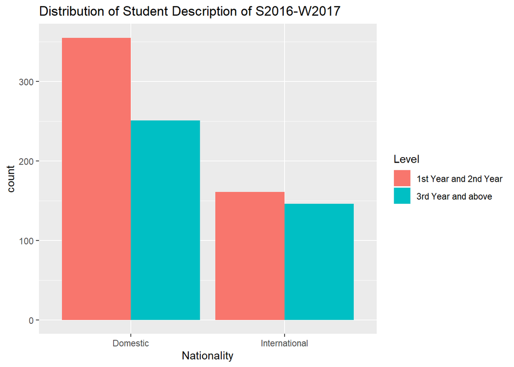

```r
# 2016-2017 only
# 1st plot of report (Nationality & Level of year)

Y16Y17_data<-newdata %>% filter(Year=="S2016-W2017")
ggplot(Y16Y17_data,aes(x=Nationality,fill=Level)) + geom_bar(position="dodge")+ xlab("Nationality") + ggtitle("Distribution of Student Description of S2016-W2017")
```

```r
# Table: summarize by Level of year
Y16Y17_data %>% group_by(Level) %>% summarize(count=n()) %>% mutate(prop = prop.table(count))
```

| Level | count | prop |
| --- | --- | --- |
| 1st Year and 2nd Year | 516 | 0.5651698 |
| 3rd Year and above | 397 | 0.4348302 |

```r
# Table: summarize by Nationality
Y16Y17_data %>% group_by(Nationality) %>% summarize(count=n()) %>% mutate(prop = prop.table(count))
```

| Nationality | count | prop |
| --- | --- | --- |
| Domestic | 606 | 0.6637459 |
| International | 307 | 0.3362541 |

```r
# Table: summarize all
Y16Y17_data %>% group_by(Level,Nationality) %>% summarize(count=n()) %>% mutate(prop = prop.table(count))
```

| Level | Nationality | count | prop |
| --- | --- | --- | --- |
| 1st Year and 2nd Year | Domestic | 355 | 0.6879845 |
| 1st Year and 2nd Year | International | 161 | 0.3120155 |
| 3rd Year and above | Domestic | 251 | 0.6322418 |
| 3rd Year and above | International | 146 | 0.3677582 |

```r
Y16Y17_data%>% summarize(count=n())
```

| count |
| --- |
| 913 |

```r
# Table: summarize by aspect of writing
kable((Y16Y17_data%>% group_by(Nationality,Aspects) %>% summarize(count=n()) %>% mutate(prop = prop.table(count))),"latex")
```

[output not shown]

#### 2.3.2 2016-2017 (Domestic students & Aspect of writing)

The plot below shows that in 2016-2017: 1. The trend for domestic under and upperclassmen is the same: both tend to focus more on the “Not include editing” 2.In total, there were about 66% domestic students focused on “Not include editing” and only 33% domestic student focused on “Include editing”.

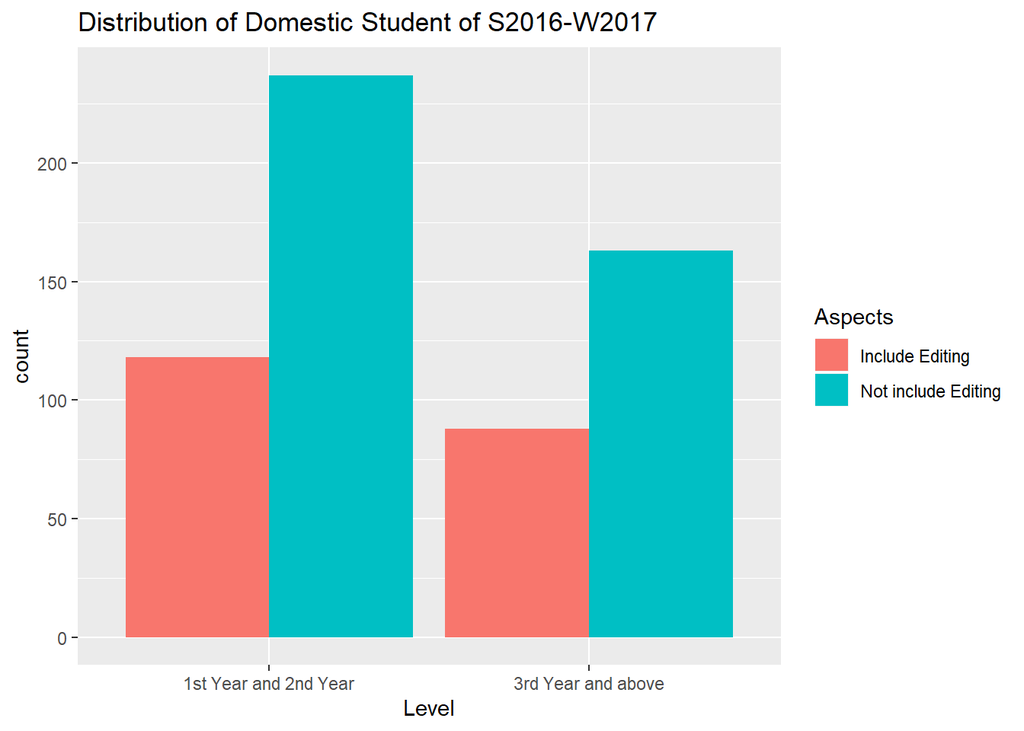

```r
# 2016-2017 only
# 2nd plot of report (Domestic & Editing/not)
ggplot((Y16Y17_data%>% filter(Nationality=="Domestic")),aes(x=Level,fill=Aspects)) + geom_bar(position="dodge")+ ggtitle("Distribution of Domestic Student of S2016-W2017")
```

```r
(Y16Y17_data%>% filter(Nationality=="Domestic")) %>% group_by(Level,Aspects) %>% summarize(count=n()) %>% mutate(prop = prop.table(count))
```

| Level | Aspects | count | prop |
| --- | --- | --- | --- |
| 1st Year and 2nd Year | Include Editing | 118 | 0.3323944 |
| 1st Year and 2nd Year | Not include Editing | 237 | 0.6676056 |
| 3rd Year and above | Include Editing | 88 | 0.3505976 |
| 3rd Year and above | Not include Editing | 163 | 0.6494024 |

```r
# Table: summarize by Level of year
(Y16Y17_data%>% filter(Nationality=="Domestic")) %>% group_by(Level) %>% summarize(count=n()) %>% mutate(prop = prop.table(count))
```

| Level | count | prop |
| --- | --- | --- |
| 1st Year and 2nd Year | 355 | 0.5858086 |
| 3rd Year and above | 251 | 0.4141914 |

```r
# Table: summarize by Nationality
(Y16Y17_data%>% filter(Nationality=="Domestic")) %>% group_by(Aspects) %>% summarize(count=n()) %>% mutate(prop = prop.table(count))
```

| Aspects | count | prop |
| --- | --- | --- |
| Include Editing | 206 | 0.339934 |
| Not include Editing | 400 | 0.660066 |

#### 2.3.3 2016-2017 (International students & Aspect of writing)

The plot below shows that in 2016-2017: 1. The total number of visits for underclassmen (52%) is slightly bigger than upperclassmen (48%) 2. Interestingly, for international students we can observe the reverse trend in aspects of writing. More underclassmen tend to focus on “not include editing”, while upperclassmen tends to focus more on the “include editing”.

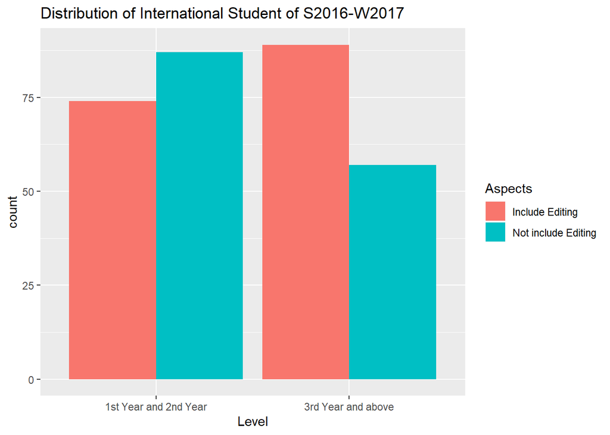

```r
# 2016-2017 only
# 3rd plot of report (International & Editing/not)
ggplot((Y16Y17_data%>% filter(Nationality=="International")),aes(x=Level,fill=Aspects)) + geom_bar(position="dodge") + ggtitle("Distribution of International Student of S2016-W2017")
```

```r
# Table: summarize by Level of year
(Y16Y17_data%>% filter(Nationality=="International")) %>% group_by(Level) %>% summarize(count=n()) %>% mutate(prop = prop.table(count))
```

| Level | count | prop |
| --- | --- | --- |
| 1st Year and 2nd Year | 161 | 0.52443 |
| 3rd Year and above | 146 | 0.47557 |

```r
# Table: summarize by Nationality
(Y16Y17_data%>% filter(Nationality=="International")) %>% group_by(Aspects) %>% summarize(count=n()) %>% mutate(prop = prop.table(count))
```

| Aspects | count | prop |
| --- | --- | --- |
| Include Editing | 163 | 0.5309446 |
| Not include Editing | 144 | 0.4690554 |

```r
# Table: summarize all
(Y16Y17_data%>% filter(Nationality=="International")) %>% group_by(Level,Aspects) %>% summarize(count=n()) %>% mutate(prop = prop.table(count))
```

| Level | Aspects | count | prop |
| --- | --- | --- | --- |
| 1st Year and 2nd Year | Include Editing | 74 | 0.4596273 |
| 1st Year and 2nd Year | Not include Editing | 87 | 0.5403727 |
| 3rd Year and above | Include Editing | 89 | 0.6095890 |
| 3rd Year and above | Not include Editing | 57 | 0.3904110 |

### 2.4 2017-2018

#### 2.4.1 2017-2018 (Overview)

In summary, the plot above shows that in 2017-2018: 1. There were more domestic students (63%) visited writing center than the international students (36%) 2. More underclassmen(61%) students visited the writing center, comparing to upperclassmen(38%) 3. Similartly to 2016-2017 data summary, we observe the similar trend for domestic/international upperclassmen and domestic/international underclassmen. More underclassmen from both groups visited the writing center more compared to upperclassmen from both groups. 4. Under each group (international & dommestic),higher proportion of international students(50%) focused on editing than domestics(34%).

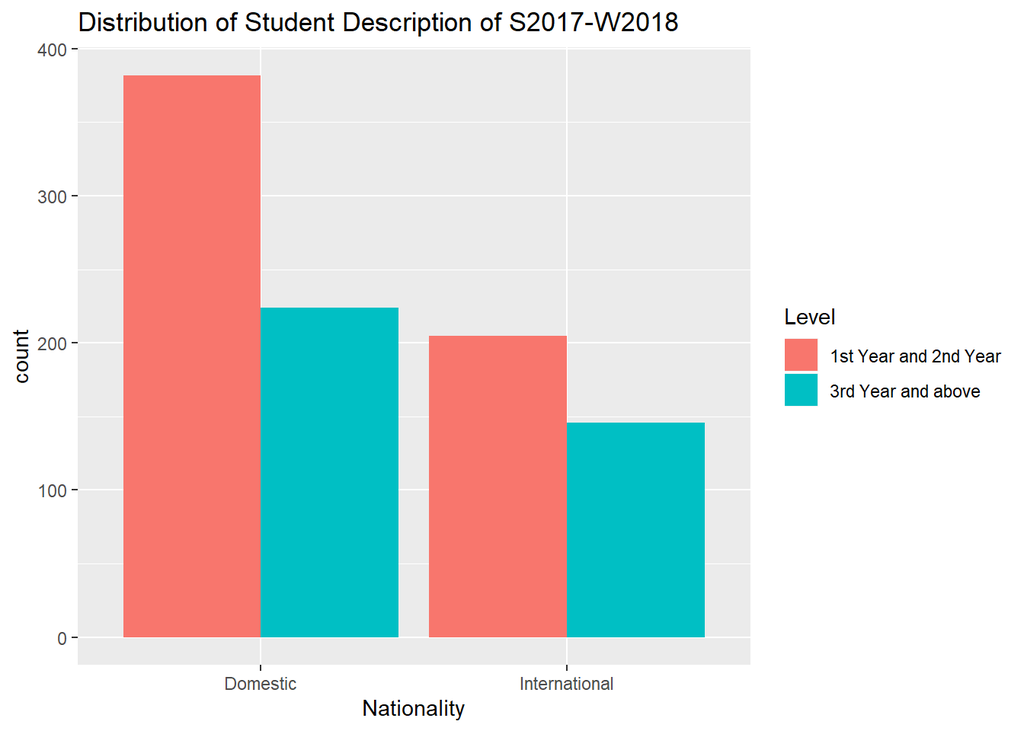

```r
# 2017-2018 only
# 1st plot of report (Nationality & Level of year)

Y17Y18_data<-newdata %>% filter(Year=="S2017-W2018")
ggplot(Y17Y18_data,aes(x=Nationality,fill=Level)) + geom_bar(position="dodge")+ xlab("Nationality") + ggtitle("Distribution of Student Description of S2017-W2018")
```

```r
# Table: summarize by Level of year
Y17Y18_data %>% group_by(Level) %>% summarize(count=n()) %>% mutate(prop = prop.table(count))
```

| Level | count | prop |
| --- | --- | --- |
| 1st Year and 2nd Year | 587 | 0.6133751 |
| 3rd Year and above | 370 | 0.3866249 |

```r
# Table: summarize by Nationality
Y17Y18_data %>% group_by(Nationality) %>% summarize(count=n()) %>% mutate(prop = prop.table(count))
```

| Nationality | count | prop |
| --- | --- | --- |
| Domestic | 606 | 0.6332288 |
| International | 351 | 0.3667712 |

```r
# Table: summarize all
Y17Y18_data %>% group_by(Level,Nationality) %>% summarize(count=n()) %>% mutate(prop = prop.table(count))
```

| Level | Nationality | count | prop |
| --- | --- | --- | --- |
| 1st Year and 2nd Year | Domestic | 382 | 0.6507666 |
| 1st Year and 2nd Year | International | 205 | 0.3492334 |
| 3rd Year and above | Domestic | 224 | 0.6054054 |
| 3rd Year and above | International | 146 | 0.3945946 |

```r
Y17Y18_data%>% summarize(count=n())
```

| count |
| --- |
| 957 |

```r
# Table: summarize by aspect of writing
Y17Y18_data%>% group_by(Nationality,Aspects) %>% summarize(count=n()) %>% mutate(prop = prop.table(count))
```

| Nationality | Aspects | count | prop |
| --- | --- | --- | --- |
| Domestic | Include Editing | 208 | 0.3432343 |
| Domestic | Not include Editing | 398 | 0.6567657 |
| International | Include Editing | 178 | 0.5071225 |
| International | Not include Editing | 173 | 0.4928775 |

#### 2.4.1 2017-2018 (Domestic students & Aspect of writing)

The plot below shows that in 2017-2018 domestic student, both underclassmen and upperclassmen tends to focus more on the “Not include editing”. In total, there were about 66% domestic students focused on “Not include editing” and only 34% domestic student focused on “Include editing”. Overall, the proportion of domestic underclassmen (63%) in the data is higher than domestic upperclassmen (37%).

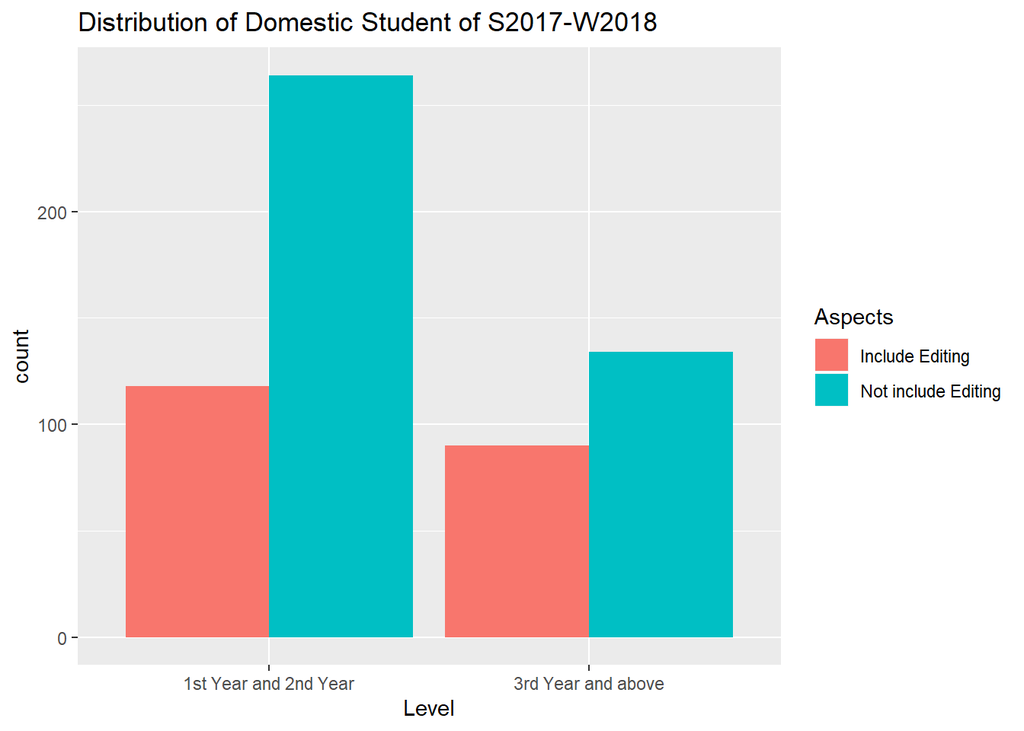

```r
# 2017-2018 only
# 2nd plot of report (Domestic & Editing/not)
ggplot((Y17Y18_data%>% filter(Nationality=="Domestic")),aes(x=Level,fill=Aspects)) + geom_bar(position="dodge")+ ggtitle("Distribution of Domestic Student of S2017-W2018")
```

```r
(Y17Y18_data%>% filter(Nationality=="Domestic")) %>% group_by(Level,Aspects) %>% summarize(count=n()) %>% mutate(prop = prop.table(count))
```

| Level | Aspects | count | prop |
| --- | --- | --- | --- |
| 1st Year and 2nd Year | Include Editing | 118 | 0.3089005 |
| 1st Year and 2nd Year | Not include Editing | 264 | 0.6910995 |
| 3rd Year and above | Include Editing | 90 | 0.4017857 |
| 3rd Year and above | Not include Editing | 134 | 0.5982143 |

```r
# Table: summarize by Level of year
(Y17Y18_data%>% filter(Nationality=="Domestic")) %>% group_by(Level) %>% summarize(count=n()) %>% mutate(prop = prop.table(count))
```

| Level | count | prop |
| --- | --- | --- |
| 1st Year and 2nd Year | 382 | 0.630363 |
| 3rd Year and above | 224 | 0.369637 |

```r
# Table: summarize by Nationality
(Y17Y18_data%>% filter(Nationality=="Domestic")) %>% group_by(Aspects) %>% summarize(count=n()) %>% mutate(prop = prop.table(count))
```

| Aspects | count | prop |
| --- | --- | --- |
| Include Editing | 208 | 0.3432343 |
| Not include Editing | 398 | 0.6567657 |

#### 2.4.1 2017-2018 (International students & Aspect of writing)

The plot below shows that in 2017-2018 international student, the proportion of international underclassmen (58%) is higher than international upperclassmen (42%). Compared with 2016-2017, more international underclassmen tends to go to the writing center for help. While similarly, underclassmen tends to focus more on the “not include editing”, upperclassmen tends to focus more on the “include editing”.

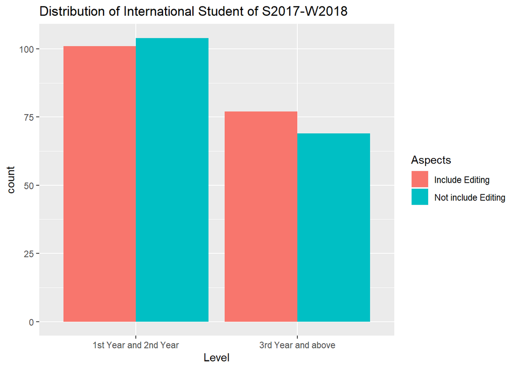

```r
# 2017-2018 only
# 3rd plot of report (International & Editing/not)
ggplot((Y17Y18_data%>% filter(Nationality=="International")),aes(x=Level,fill=Aspects)) + geom_bar(position="dodge") + ggtitle("Distribution of International Student of S2017-W2018")
```

```r
# Table: summarize by Level of year
(Y17Y18_data%>% filter(Nationality=="International")) %>% group_by(Level) %>% summarize(count=n()) %>% mutate(prop = prop.table(count))
```

| Level | count | prop |
| --- | --- | --- |
| 1st Year and 2nd Year | 205 | 0.5840456 |
| 3rd Year and above | 146 | 0.4159544 |

```r
# Table: summarize by Nationality
(Y17Y18_data%>% filter(Nationality=="International")) %>% group_by(Aspects) %>% summarize(count=n()) %>% mutate(prop = prop.table(count))
```

| Aspects | count | prop |
| --- | --- | --- |
| Include Editing | 178 | 0.5071225 |
| Not include Editing | 173 | 0.4928775 |

```r
# Table: summarize all
(Y17Y18_data%>% filter(Nationality=="International")) %>% group_by(Level,Aspects) %>% summarize(count=n()) %>% mutate(prop = prop.table(count))
```

| Level | Aspects | count | prop |
| --- | --- | --- | --- |
| 1st Year and 2nd Year | Include Editing | 101 | 0.4926829 |
| 1st Year and 2nd Year | Not include Editing | 104 | 0.5073171 |
| 3rd Year and above | Include Editing | 77 | 0.5273973 |
| 3rd Year and above | Not include Editing | 69 | 0.4726027 |

## 2.5 Logistic regression model

### 2016-2017 (Model 1: no interaction)

Since both 2016-2017 and 2017-2018 were following similar trends, we have reason to believe they will show similar pattern when implementing data analysis. Data analysis using logistic regression model seems to be more fitting, since most of the variables are categorical and our response suppose to be binary. We take our Types of assingment as a predictor. The Analytical Essay is our base variable, which we compare to the rest of the Types Of Assignment. However, we also have to check if there is an interaction effect between Year of Study and Nationality. Therefore we fit the data into two different types of model which one has interaction and one without interaction. The following is a summary of the fitted logistic regression model without interaction.

Model 1 - Analytical Essay as base, no interaction between Year of Study and Nationality:

```
##
## Call:
## glm(formula = Editing.and.revising ~ Level + Nationality + Assignment_type,
##     family = binomial(logit), data = Y16Y17_data)
##
## Deviance Residuals:
##     Min       1Q   Median       3Q      Max
## -1.8713  -0.9619  -0.8428   1.1947   1.8403
##
## Coefficients:
##                                        Estimate Std. Error z value Pr(>|z|)
## (Intercept)                            -0.82846    0.12652  -6.548 5.82e-11 ***
## Level3rd Year and above                 0.32165    0.14495   2.219 0.026480 *
## NationalityInternational                0.78773    0.14661   5.373 7.74e-08 ***
## Assignment_typeAnnotated.Bibliography -14.32597  417.15221  -0.034 0.972604
## Assignment_typeCritical.Review         -0.24355    0.23081  -1.055 0.291325
## Assignment_typeJournal.Entry            0.93215    0.42421   2.197 0.027992 *
## Assignment_typeLab.Report               1.27915    0.35447   3.609 0.000308 ***
## Assignment_typeLiterature.Review       -0.02558    0.40948  -0.062 0.950187
## Assignment_typePersonal.Statement       1.28563    0.83606   1.538 0.124116
## Assignment_typeProposal                -0.66178    0.34982  -1.892 0.058524 .
## Assignment_typeResearch.Essay          -0.02388    0.17100  -0.140 0.888941
## ---
## Signif. codes:  0 '***' 0.001 '**' 0.01 '*' 0.05 '.' 0.1 ' ' 1
##
## (Dispersion parameter for binomial family taken to be 1)
##
##     Null deviance: 1231.9  on 912  degrees of freedom
## Residual deviance: 1163.2  on 902  degrees of freedom
## AIC: 1185.2
##
## Number of Fisher Scoring iterations: 13
```

### 2016-2017 (Model 2: with interaction)

Model 2 Analytical Essay as base, interaction between Year of Study and Nationality:

```
##
## Call:
## glm(formula = Editing.and.revising ~ Level + Nationality + Assignment_type +
##     Level:Nationality, family = binomial(logit), data = Y16Y17_data)
##
## Deviance Residuals:
##     Min       1Q   Median       3Q      Max
## -1.9411  -0.9172  -0.8468   1.2582   1.8039
##
## Coefficients:
##                                                   Estimate Std. Error z value
## (Intercept)                                       -0.74351    0.13433  -5.535
## Level3rd Year and above                            0.13747    0.17973   0.765
## NationalityInternational                           0.55553    0.19801   2.806
## Assignment_typeAnnotated.Bibliography            -14.46492  412.63280  -0.035
## Assignment_typeCritical.Review                    -0.23512    0.23108  -1.017
## Assignment_typeJournal.Entry                       0.91083    0.42476   2.144
## Assignment_typeLab.Report                          1.25354    0.35415   3.540
## Assignment_typeLiterature.Review                  -0.03770    0.41426  -0.091
## Assignment_typePersonal.Statement                  1.31276    0.84302   1.557
## Assignment_typeProposal                           -0.66475    0.35214  -1.888
## Assignment_typeResearch.Essay                     -0.04221    0.17179  -0.246
## Level3rd Year and above:NationalityInternational   0.51596    0.29677   1.739
##                                                  Pr(>|z|)
## (Intercept)                                      3.11e-08 ***
## Level3rd Year and above                          0.444361
## NationalityInternational                         0.005022 **
## Assignment_typeAnnotated.Bibliography            0.972036
## Assignment_typeCritical.Review                   0.308928
## Assignment_typeJournal.Entry                     0.032005 *
## Assignment_typeLab.Report                        0.000401 ***
## Assignment_typeLiterature.Review                 0.927481
## Assignment_typePersonal.Statement                0.119422
## Assignment_typeProposal                          0.059059 .
## Assignment_typeResearch.Essay                    0.805924
## Level3rd Year and above:NationalityInternational 0.082102 .
## ---
## Signif. codes:  0 '***' 0.001 '**' 0.01 '*' 0.05 '.' 0.1 ' ' 1
##
## (Dispersion parameter for binomial family taken to be 1)
##
##     Null deviance: 1231.9  on 912  degrees of freedom
## Residual deviance: 1160.2  on 901  degrees of freedom
## AIC: 1184.2
##
## Number of Fisher Scoring iterations: 13
```

Both models show that the Nationality is significant model1(P-value=7.74e-08) and model2(P-value=0.005022). International students in years 2016-2017 are e^0.78773*100%=220% more likely to work on editing than withouht editing for their type of writing. Smimilarly to previous findings, we can see that working on a Lab Report type of assingment will increase the odds by e^1.27915*100%=359%, while working on a Critical review will decrease the odds.

## 2.6 logistic regression model

### 2017-2018 (Model 1: no interaction)

The following is a summary of the fitted logistic regression model. Model 1 - Analytical Essay as base, no interaction between Year of Study and Nationality:

```
##
## Call:
## glm(formula = Editing.and.revising ~ Level + Nationality + Assignment_type,
##     family = binomial(logit), data = Y17Y18_data)
##
## Deviance Residuals:
##     Min       1Q   Median       3Q      Max
## -1.6906  -0.9700  -0.8292   1.2396   1.9404
##
## Coefficients:
##                                       Estimate Std. Error z value Pr(>|z|)
## (Intercept)                            -0.8910     0.1192  -7.474 7.76e-14 ***
## Level3rd Year and above                 0.3815     0.1418   2.690  0.00715 **
## NationalityInternational                0.6992     0.1408   4.966 6.84e-07 ***
## Assignment_typeAnnotated.Bibliography  -0.3342     0.6284  -0.532  0.59484
## Assignment_typeCritical.Review         -0.5930     0.2721  -2.179  0.02934 *
## Assignment_typeJournal.Entry            0.4243     0.6849   0.619  0.53565
## Assignment_typeLab.Report               1.3470     0.3308   4.072 4.67e-05 ***
## Assignment_typeLiterature.Review       -0.8264     0.4547  -1.818  0.06912 .
## Assignment_typePersonal.Statement      -0.5450     0.7143  -0.763  0.44550
## Assignment_typeProposal                -0.2544     0.4079  -0.624  0.53291
## Assignment_typeResearch.Essay           0.3645     0.1610   2.264  0.02360 *
## ---
## Signif. codes:  0 '***' 0.001 '**' 0.01 '*' 0.05 '.' 0.1 ' ' 1
##
## (Dispersion parameter for binomial family taken to be 1)
##
##     Null deviance: 1290.7  on 956  degrees of freedom
## Residual deviance: 1223.8  on 946  degrees of freedom
## AIC: 1245.8
##
## Number of Fisher Scoring iterations: 4
```

### 2017-2018 (Model 2: with interaction)

Model 2 Analytical Essay as base, interaction between Year of Study and Nationality:

```
##
## Call:
## glm(formula = Editing.and.revising ~ Level + Nationality + Assignment_type +
##     Level:Nationality, family = binomial(logit), data = Y17Y18_data)
##
## Deviance Residuals:
##     Min       1Q   Median       3Q      Max
## -1.7042  -0.9836  -0.8221   1.2268   1.9461
##
## Coefficients:
##                                                  Estimate Std. Error z value
## (Intercept)                                       -0.9111     0.1265  -7.204
## Level3rd Year and above                            0.4364     0.1810   2.411
## NationalityInternational                           0.7563     0.1831   4.130
## Assignment_typeAnnotated.Bibliography             -0.3465     0.6283  -0.551
## Assignment_typeCritical.Review                    -0.5945     0.2720  -2.186
## Assignment_typeJournal.Entry                       0.4188     0.6864   0.610
## Assignment_typeLab.Report                          1.3404     0.3316   4.042
## Assignment_typeLiterature.Review                  -0.8194     0.4541  -1.804
## Assignment_typePersonal.Statement                 -0.5275     0.7137  -0.739
## Assignment_typeProposal                           -0.2497     0.4076  -0.613
## Assignment_typeResearch.Essay                      0.3594     0.1614   2.227
## Level3rd Year and above:NationalityInternational  -0.1396     0.2861  -0.488
##                                                  Pr(>|z|)
## (Intercept)                                      5.84e-13 ***
## Level3rd Year and above                            0.0159 *
## NationalityInternational                         3.63e-05 ***
## Assignment_typeAnnotated.Bibliography              0.5813
## Assignment_typeCritical.Review                     0.0288 *
## Assignment_typeJournal.Entry                       0.5418
## Assignment_typeLab.Report                        5.30e-05 ***
## Assignment_typeLiterature.Review                   0.0712 .
## Assignment_typePersonal.Statement                  0.4599
## Assignment_typeProposal                            0.5401
## Assignment_typeResearch.Essay                      0.0260 *
## Level3rd Year and above:NationalityInternational   0.6255
## ---
## Signif. codes:  0 '***' 0.001 '**' 0.01 '*' 0.05 '.' 0.1 ' ' 1
##
## (Dispersion parameter for binomial family taken to be 1)
##
##     Null deviance: 1290.7  on 956  degrees of freedom
## Residual deviance: 1223.6  on 945  degrees of freedom
## AIC: 1247.6
##
## Number of Fisher Scoring iterations: 4
```

To summarize the findings, Model 1.1 shows that the level of Year is significant and Model 2.1 shows significant as well. Moreover, the interaction term is not significant. Perhaps, it confirms the previous findings from the frequency table that there are some changes in the data distribution than previous year. To be more specific, in 2017-2018 international student, the proportion of international underclassmen (58%) is higher than international upperclassmen (42%). While in 2016-2017, those two categories have similar proportion (around 50%). Therefore in Year 2017-2018 is indeed significant for the 2017-2018 data.

### 2.7 2016-2018

#### 2016-2018 (Overview)

In summary, the plot above shows that in 2016-2018: 1. There were more domestic students (65%) visited writing center than the international students (35%), while at the same time, under both international/dommestic the underclassmen visited more than upperclassmen. The trend is similar to previous findings. 2. More underclassmen(59%) students visited the writing center, comparing to upperclassmen(41%) 3. More domestic students focus on not include editing for both underclassmen and upperclassmen categories. 4. More underclassmen international students focus on not include editing, while among the upperclassmen group more students focus on include editing. 5. Also, under each group (international & dommestic),higher proportion of international students(52%) focused on editing than domestics(34%).

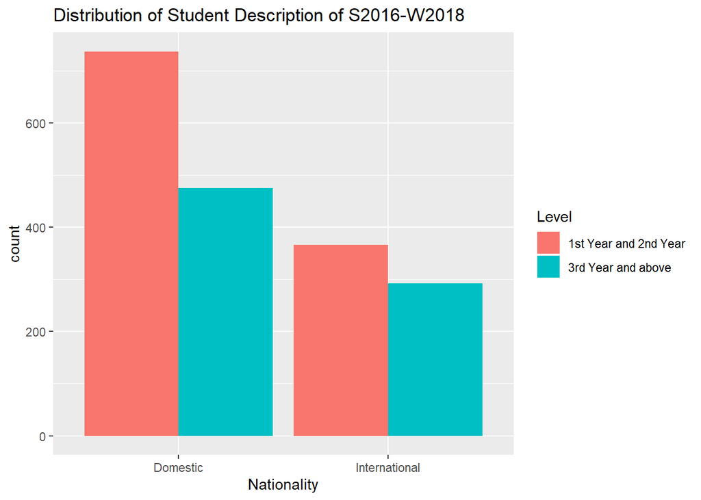

```r
# 4th plot of report

# 2016-2018
# 1st plot of report (Nationality & Level of year)
Y16Y18_data<-newdata %>% filter(Year=="S2017-W2018"| Year=="S2016-W2017")
ggplot(Y16Y18_data,aes(x=Nationality,fill=Level)) + geom_bar(position="dodge")+ xlab("Nationality") + ggtitle("Distribution of Student Description of S2016-W2018")
```

```r
# Table: summarize by Level of year
Y16Y18_data %>% group_by(Level) %>% summarize(count=n()) %>% mutate(prop = prop.table(count))
```

| Level | count | prop |
| --- | --- | --- |
| 1st Year and 2nd Year | 1103 | 0.5898396 |
| 3rd Year and above | 767 | 0.4101604 |

```r
# Table: summarize by Nationality
Y16Y18_data %>% group_by(Nationality) %>% summarize(count=n()) %>% mutate(prop = prop.table(count))
```

| Nationality | count | prop |
| --- | --- | --- |
| Domestic | 1212 | 0.6481283 |
| International | 658 | 0.3518717 |

```r
# Table: summarize all
Y16Y18_data %>% group_by(Level,Nationality) %>% summarize(count=n()) %>% mutate(prop = prop.table(count))
```

| Level | Nationality | count | prop |
| --- | --- | --- | --- |
| 1st Year and 2nd Year | Domestic | 737 | 0.6681777 |
| 1st Year and 2nd Year | International | 366 | 0.3318223 |
| 3rd Year and above | Domestic | 475 | 0.6192960 |
| 3rd Year and above | International | 292 | 0.3807040 |

```r
Y16Y18_data%>% summarize(count=n())
```

| count |
| --- |
| 1870 |

```r
Y16Y18_data %>% group_by(Level,Aspects,Nationality) %>% summarize(count=n()) %>% mutate(prop = prop.table(count))
```

| Level | Aspects | Nationality | count | prop |
| --- | --- | --- | --- | --- |
| 1st Year and 2nd Year | Include Editing | Domestic | 236 | 0.5742092 |
| 1st Year and 2nd Year | Include Editing | International | 175 | 0.4257908 |
| 1st Year and 2nd Year | Not include Editing | Domestic | 501 | 0.7239884 |
| 1st Year and 2nd Year | Not include Editing | International | 191 | 0.2760116 |
| 3rd Year and above | Include Editing | Domestic | 178 | 0.5174419 |
| 3rd Year and above | Include Editing | International | 166 | 0.4825581 |
| 3rd Year and above | Not include Editing | Domestic | 297 | 0.7021277 |
| 3rd Year and above | Not include Editing | International | 126 | 0.2978723 |

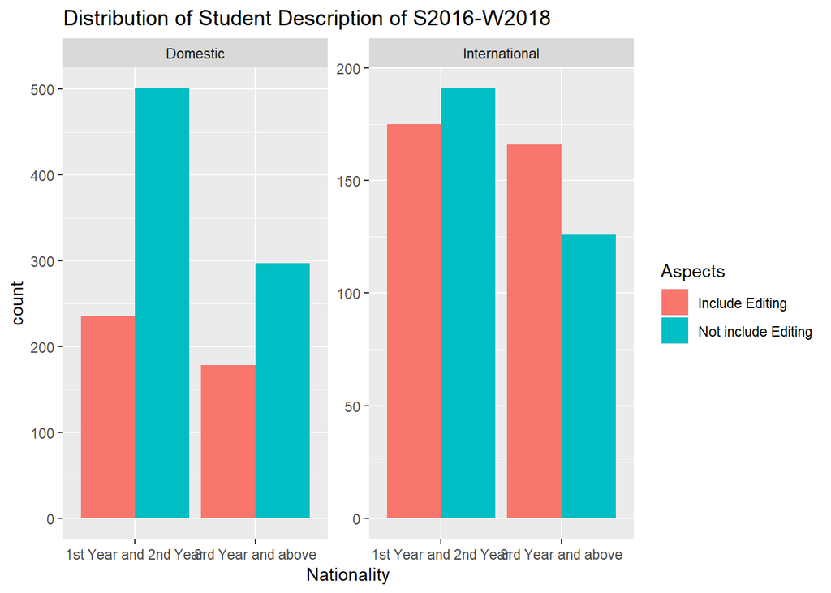

```r
ggplot(Y16Y18_data,aes(x=Level,fill=Aspects)) + geom_bar(position="dodge")+ xlab("Nationality") + ggtitle("Distribution of Student Description of S2016-W2018") +facet_wrap(~Nationality,scales="free",ncol=2)
```

```r
(Y16Y18_data %>% group_by(Nationality,Aspects) %>% summarize(count=n()) %>% mutate(prop = prop.table(count)))
```

| Nationality | Aspects | count | prop |
| --- | --- | --- | --- |
| Domestic | Include Editing | 414 | 0.3415842 |
| Domestic | Not include Editing | 798 | 0.6584158 |
| International | Include Editing | 341 | 0.5182371 |
| International | Not include Editing | 317 | 0.4817629 |

### 2016-2018 (Domestic students & Aspect of writing)

The plot below shows that in 2016-2018 domestic student, both underclassmen and upperclassmen tends to focus more on the “Not include editing”. In total, there were about 66% domestic students focused on “Not include editing” and only 34% domestic student focused on “Include editing”. Overall, the proportion of domestic underclassmen (61%) in the data is higher than domestic upperclassmen (39%).

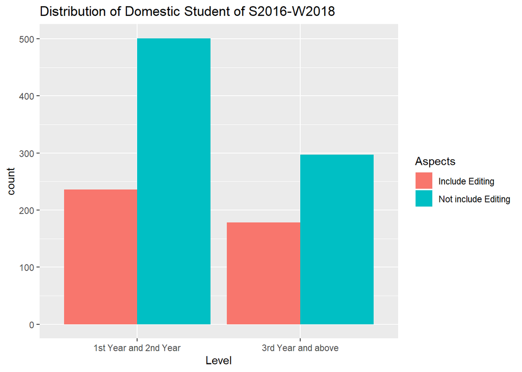

```r
# 2016-2018
# 2nd plot of report (Domestic & Editing/not)
ggplot((Y16Y18_data%>% filter(Nationality=="Domestic")),aes(x=Level,fill=Aspects)) + geom_bar(position="dodge")+ ggtitle("Distribution of Domestic Student of S2016-W2018")
```

```r
(Y16Y18_data%>% filter(Nationality=="Domestic")) %>% group_by(Level,Aspects) %>% summarize(count=n()) %>% mutate(prop = prop.table(count))
```

| Level | Aspects | count | prop |
| --- | --- | --- | --- |
| 1st Year and 2nd Year | Include Editing | 236 | 0.3202171 |
| 1st Year and 2nd Year | Not include Editing | 501 | 0.6797829 |
| 3rd Year and above | Include Editing | 178 | 0.3747368 |
| 3rd Year and above | Not include Editing | 297 | 0.6252632 |

```r
# Table: summarize by Level of year
(Y16Y18_data%>% filter(Nationality=="Domestic")) %>% group_by(Level) %>% summarize(count=n()) %>% mutate(prop = prop.table(count))
```

| Level | count | prop |
| --- | --- | --- |
| 1st Year and 2nd Year | 737 | 0.6080858 |
| 3rd Year and above | 475 | 0.3919142 |

```r
# Table: summarize by Nationality
(Y16Y18_data%>% filter(Nationality=="Domestic")) %>% group_by(Aspects) %>% summarize(count=n()) %>% mutate(prop = prop.table(count))
```

| Aspects | count | prop |
| --- | --- | --- |
| Include Editing | 414 | 0.3415842 |
| Not include Editing | 798 | 0.6584158 |

### 2016-2018 (International students & Aspect of writing)

The plot below shows that in 2016-2018 international student, the proportion of international underclassmen (56%) is higher than international upperclassmen (44%). While similarly, underclassmen tends to focus more on the “not include editing”, upperclassmen tends to focus more on the “include editing”.

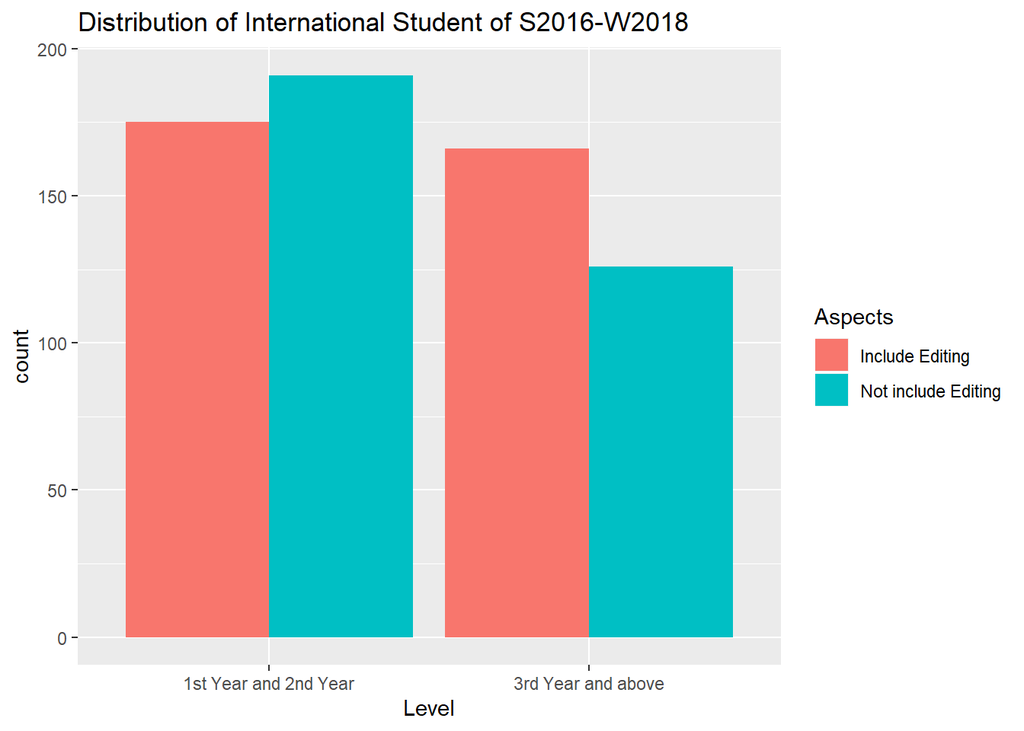

```r
# 2016-2018
# 3rd plot of report (International & Editing/not)
ggplot((Y16Y18_data%>% filter(Nationality=="International")),aes(x=Level,fill=Aspects)) + geom_bar(position="dodge") + ggtitle("Distribution of International Student of S2016-W2018")
```

```r
# Table: summarize by Level of year
(Y16Y18_data%>% filter(Nationality=="International")) %>% group_by(Level) %>% summarize(count=n()) %>% mutate(prop = prop.table(count))
```

| Level | count | prop |
| --- | --- | --- |
| 1st Year and 2nd Year | 366 | 0.556231 |
| 3rd Year and above | 292 | 0.443769 |

```r
# Table: summarize by Nationality
(Y16Y18_data%>% filter(Nationality=="International")) %>% group_by(Aspects) %>% summarize(count=n()) %>% mutate(prop = prop.table(count))
```

| Aspects | count | prop |
| --- | --- | --- |
| Include Editing | 341 | 0.5182371 |
| Not include Editing | 317 | 0.4817629 |

```r
# Table: summarize all
(Y16Y18_data%>% filter(Nationality=="International")) %>% group_by(Level,Aspects) %>% summarize(count=n()) %>% mutate(prop = prop.table(count))
```

| Level | Aspects | count | prop |
| --- | --- | --- | --- |
| 1st Year and 2nd Year | Include Editing | 175 | 0.4781421 |
| 1st Year and 2nd Year | Not include Editing | 191 | 0.5218579 |
| 3rd Year and above | Include Editing | 166 | 0.5684932 |
| 3rd Year and above | Not include Editing | 126 | 0.4315068 |

### 2016-2018 Regression model (Model 1: no interaction)

Model 1 Analytical Essay as base, no interaction between Year of Study and Nationality:

```
##
## Call:
## glm(formula = Editing.and.revising ~ Level + Nationality + Assignment_type,
##     family = binomial(logit), data = Y16Y18_data)
##
## Deviance Residuals:
##     Min       1Q   Median       3Q      Max
## -1.8647  -0.9710  -0.8395   1.2320   1.7776
##
## Coefficients:
##                                       Estimate Std. Error z value Pr(>|z|)
## (Intercept)                           -0.86168    0.08649  -9.962  < 2e-16 ***
## Level3rd Year and above                0.35453    0.10081   3.517 0.000437 ***
## NationalityInternational               0.73422    0.10092   7.275 3.47e-13 ***
## Assignment_typeAnnotated.Bibliography -0.79846    0.59132  -1.350 0.176920
## Assignment_typeCritical.Review        -0.38145    0.17449  -2.186 0.028808 *
## Assignment_typeJournal.Entry           0.81211    0.35475   2.289 0.022064 *
## Assignment_typeLab.Report              1.31820    0.24172   5.453 4.94e-08 ***
## Assignment_typeLiterature.Review      -0.40172    0.29799  -1.348 0.177628
## Assignment_typePersonal.Statement      0.25988    0.48870   0.532 0.594889
## Assignment_typeProposal               -0.48754    0.26423  -1.845 0.065023 .
## Assignment_typeResearch.Essay          0.17693    0.11688   1.514 0.130100
## ---
## Signif. codes:  0 '***' 0.001 '**' 0.01 '*' 0.05 '.' 0.1 ' ' 1
##
## (Dispersion parameter for binomial family taken to be 1)
##
##     Null deviance: 2522.6  on 1869  degrees of freedom
## Residual deviance: 2401.6  on 1859  degrees of freedom
## AIC: 2423.6
##
## Number of Fisher Scoring iterations: 4
```

### 2016-2018 Regression model (Model 2: with interaction)

Model 2 Analytical Essay as base, interaction between Year of Study and Nationality:

```
##
## Call:
## glm(formula = Editing.and.revising ~ Level + Nationality + Assignment_type +
##     Level:Nationality, family = binomial(logit), data = Y16Y18_data)
##
## Deviance Residuals:
##     Min       1Q   Median       3Q      Max
## -1.8839  -0.9602  -0.8464   1.2470   1.7716
##
## Coefficients:
##                                                  Estimate Std. Error z value
## (Intercept)                                      -0.84221    0.09186  -9.169
## Level3rd Year and above                           0.30717    0.12679   2.423
## NationalityInternational                          0.68015    0.13367   5.088
## Assignment_typeAnnotated.Bibliography            -0.80079    0.59214  -1.352
## Assignment_typeCritical.Review                   -0.37908    0.17458  -2.171
## Assignment_typeJournal.Entry                      0.80979    0.35466   2.283
## Assignment_typeLab.Report                         1.31821    0.24150   5.459
## Assignment_typeLiterature.Review                 -0.40638    0.29873  -1.360
## Assignment_typePersonal.Statement                 0.25330    0.48991   0.517
## Assignment_typeProposal                          -0.48892    0.26457  -1.848
## Assignment_typeResearch.Essay                     0.17748    0.11691   1.518
## Level3rd Year and above:NationalityInternational  0.12544    0.20357   0.616
##                                                  Pr(>|z|)
## (Intercept)                                       < 2e-16 ***
## Level3rd Year and above                            0.0154 *
## NationalityInternational                         3.61e-07 ***
## Assignment_typeAnnotated.Bibliography              0.1763
## Assignment_typeCritical.Review                     0.0299 *
## Assignment_typeJournal.Entry                       0.0224 *
## Assignment_typeLab.Report                        4.80e-08 ***
## Assignment_typeLiterature.Review                   0.1737
## Assignment_typePersonal.Statement                  0.6051
## Assignment_typeProposal                            0.0646 .
## Assignment_typeResearch.Essay                      0.1290
## Level3rd Year and above:NationalityInternational   0.5378
## ---
## Signif. codes:  0 '***' 0.001 '**' 0.01 '*' 0.05 '.' 0.1 ' ' 1
##
## (Dispersion parameter for binomial family taken to be 1)
##
##     Null deviance: 2522.6  on 1869  degrees of freedom
## Residual deviance: 2401.2  on 1858  degrees of freedom
## AIC: 2425.2
##
## Number of Fisher Scoring iterations: 4
```

The logistic model with the combined data shows that both Nationality and Year are indeed a significant variable (p-value < 0.05). We, therefore, discard our previous assumption that year is not significant and we will keep both of them in the regression model.

### 2.8 2014-2018

#### 2014-2018 (Overview)

In summary, the plot shows that in 2014-2018: 1. There were more domestic students (68%) visited writing center than the international students (32%), while at the same time, under both international/dommestic the underclassmen visited more than upperclassmen. 2. Under each group (international & dommestic),higher proportion of international students(50%) focused on editing than domestics(31%). 3. More domestic students focus on not include editing for both underclassmen and upperclassmen categories. 4. Simililarly to previous findings, more underclassmen international students focus on not include editing, while among the upperclassmen group more students focus on include editing.

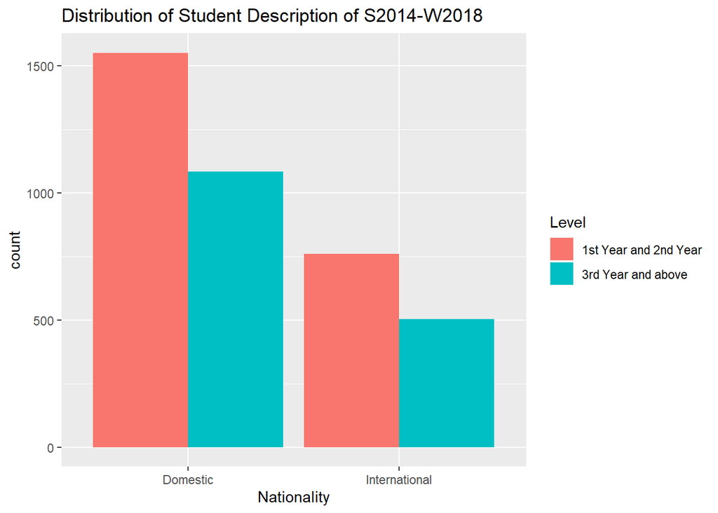

```r
# 4th plot of report

# 2014-2018
# 1st plot of report (Nationality & Level of year)
Y14Y18_data<-newdata
ggplot(Y14Y18_data,aes(x=Nationality,fill=Level)) + geom_bar(position="dodge")+ xlab("Nationality") + ggtitle("Distribution of Student Description of S2014-W2018")
```

```r
# Table: summarize by Level of year
Y14Y18_data %>% group_by(Level) %>% summarize(count=n()) %>% mutate(prop = prop.table(count))
```

| Level | count | prop |
| --- | --- | --- |
| 1st Year and 2nd Year | 2311 | 0.5930203 |
| 3rd Year and above | 1586 | 0.4069797 |

```r
# Table: summarize by Nationality
Y14Y18_data %>% group_by(Nationality) %>% summarize(count=n()) %>% mutate(prop = prop.table(count))
```

| Nationality | count | prop |
| --- | --- | --- |
| Domestic | 2634 | 0.6759045 |
| International | 1263 | 0.3240955 |

```r
# Table: summarize all
Y14Y18_data %>% group_by(Level,Nationality) %>% summarize(count=n()) %>% mutate(prop = prop.table(count))
```

| Level | Nationality | count | prop |
| --- | --- | --- | --- |
| 1st Year and 2nd Year | Domestic | 1551 | 0.6711380 |
| 1st Year and 2nd Year | International | 760 | 0.3288620 |
| 3rd Year and above | Domestic | 1083 | 0.6828499 |
| 3rd Year and above | International | 503 | 0.3171501 |

```r
Y14Y18_data%>% summarize(count=n())
```

| count |
| --- |
| 3897 |

```r
Y14Y18_data %>% group_by(Level,Aspects,Nationality) %>% summarize(count=n()) %>% mutate(prop = prop.table(count))
```

| Level | Aspects | Nationality | count | prop |
| --- | --- | --- | --- | --- |
| 1st Year and 2nd Year | Include Editing | Domestic | 464 | 0.5644769 |
| 1st Year and 2nd Year | Include Editing | International | 358 | 0.4355231 |
| 1st Year and 2nd Year | Not include Editing | Domestic | 1087 | 0.7300201 |
| 1st Year and 2nd Year | Not include Editing | International | 402 | 0.2699799 |
| 3rd Year and above | Include Editing | Domestic | 361 | 0.5640625 |
| 3rd Year and above | Include Editing | International | 279 | 0.4359375 |
| 3rd Year and above | Not include Editing | Domestic | 722 | 0.7632135 |
| 3rd Year and above | Not include Editing | International | 224 | 0.2367865 |

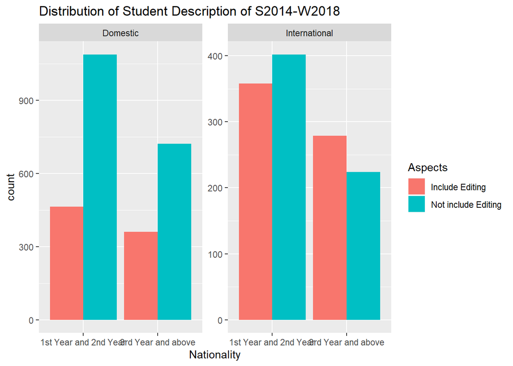

```r
ggplot(Y14Y18_data,aes(x=Level,fill=Aspects)) + geom_bar(position="dodge")+ xlab("Nationality") + ggtitle("Distribution of Student Description of S2014-W2018") +facet_wrap(~Nationality,scales="free",ncol=2)
```

```r
(Y14Y18_data %>% group_by(Nationality,Aspects) %>% summarize(count=n()) %>% mutate(prop = prop.table(count)))
```

| Nationality | Aspects | count | prop |
| --- | --- | --- | --- |
| Domestic | Include Editing | 825 | 0.3132118 |
| Domestic | Not include Editing | 1809 | 0.6867882 |
| International | Include Editing | 637 | 0.5043547 |
| International | Not include Editing | 626 | 0.4956453 |

### 2014-2018 (Domestic students & Aspect of writing)

The plot below shows that in 2014-2018 domestic student, both underclassmen and upperclassmen tends to focus more on the “Not include editing”. In total, there were about 69% domestic students focused on “Not include editing” and only 31% domestic student focused on “Include editing”. Overall, the proportion of domestic underclassmen (59%) in the data is higher than domestic upperclassmen (41%).

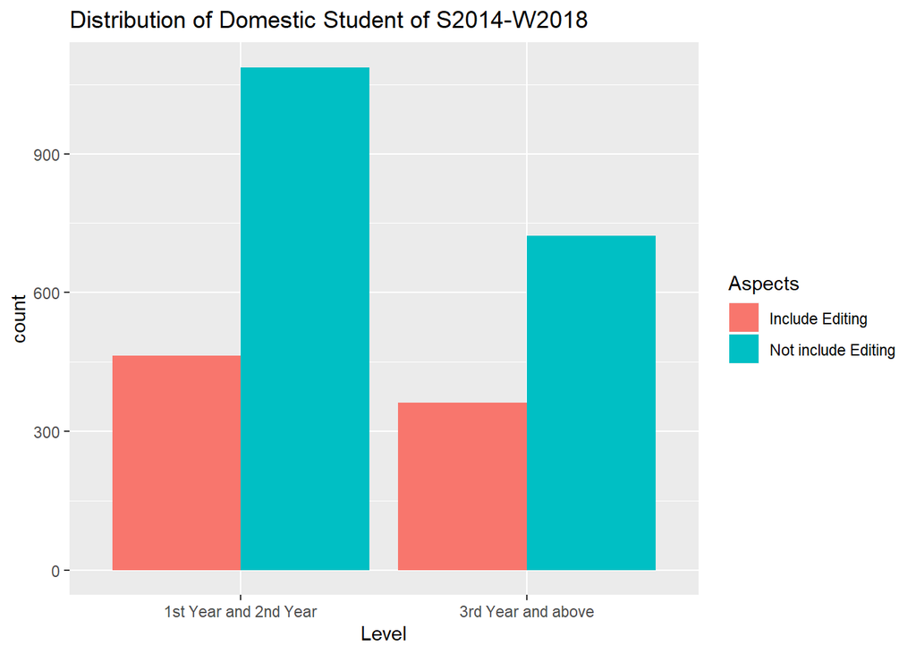

```r
# 2014-2018
# 2nd plot of report (Domestic & Editing/not)
ggplot((Y14Y18_data%>% filter(Nationality=="Domestic")),aes(x=Level,fill=Aspects)) + geom_bar(position="dodge")+ ggtitle("Distribution of Domestic Student of S2014-W2018")
```

```r
(Y14Y18_data%>% filter(Nationality=="Domestic")) %>% group_by(Level,Aspects) %>% summarize(count=n()) %>% mutate(prop = prop.table(count))
```

| Level | Aspects | count | prop |
| --- | --- | --- | --- |
| 1st Year and 2nd Year | Include Editing | 464 | 0.2991618 |
| 1st Year and 2nd Year | Not include Editing | 1087 | 0.7008382 |
| 3rd Year and above | Include Editing | 361 | 0.3333333 |
| 3rd Year and above | Not include Editing | 722 | 0.6666667 |

```r
# Table: summarize by Level of year
(Y14Y18_data%>% filter(Nationality=="Domestic")) %>% group_by(Level) %>% summarize(count=n()) %>% mutate(prop = prop.table(count))
```

| Level | count | prop |
| --- | --- | --- |
| 1st Year and 2nd Year | 1551 | 0.5888383 |
| 3rd Year and above | 1083 | 0.4111617 |

```r
# Table: summarize by Nationality
(Y14Y18_data%>% filter(Nationality=="Domestic")) %>% group_by(Aspects) %>% summarize(count=n()) %>% mutate(prop = prop.table(count))
```

| Aspects | count | prop |
| --- | --- | --- |
| Include Editing | 825 | 0.3132118 |
| Not include Editing | 1809 | 0.6867882 |

### 2014-2018 (International students & Aspect of writing)

The plot below shows that in 2014-2018 international student, the proportion of international underclassmen (60%) is higher than international upperclassmen (40%). While similarly, underclassmen tends to focus more on the “not include editing”, upperclassmen tends to focus more on the “include editing”.

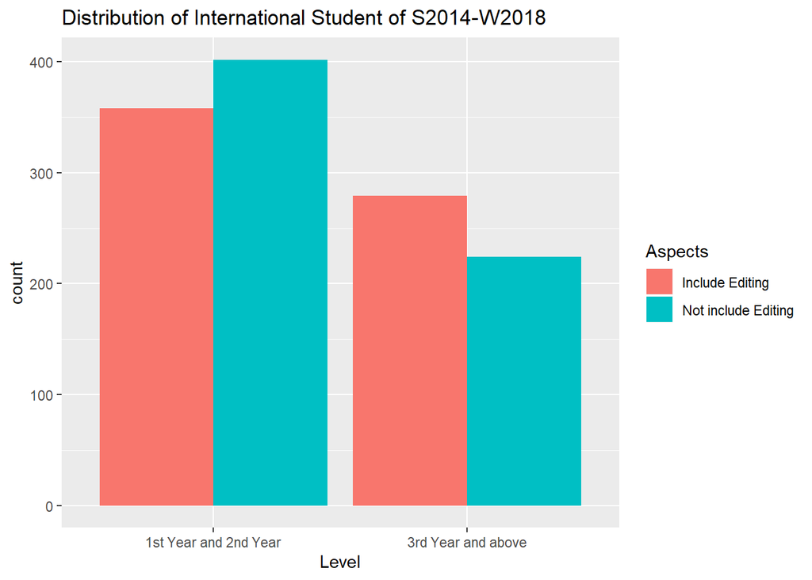

```r
# 2014-2018
# 3rd plot of report (International & Editing/not)
ggplot((Y14Y18_data%>% filter(Nationality=="International")),aes(x=Level,fill=Aspects)) + geom_bar(position="dodge") + ggtitle("Distribution of International Student of S2014-W2018")
```

```r
# Table: summarize by Level of year
(Y14Y18_data%>% filter(Nationality=="International")) %>% group_by(Level) %>% summarize(count=n()) %>% mutate(prop = prop.table(count))
```

| Level | count | prop |
| --- | --- | --- |
| 1st Year and 2nd Year | 760 | 0.6017419 |
| 3rd Year and above | 503 | 0.3982581 |

```r
# Table: summarize by Nationality
(Y14Y18_data%>% filter(Nationality=="International")) %>% group_by(Aspects) %>% summarize(count=n()) %>% mutate(prop = prop.table(count))
```

| Aspects | count | prop |
| --- | --- | --- |
| Include Editing | 637 | 0.5043547 |
| Not include Editing | 626 | 0.4956453 |

```r
# Table: summarize all
(Y14Y18_data%>% filter(Nationality=="International")) %>% group_by(Level,Aspects) %>% summarize(count=n()) %>% mutate(prop = prop.table(count))
```

| Level | Aspects | count | prop |
| --- | --- | --- | --- |
| 1st Year and 2nd Year | Include Editing | 358 | 0.4710526 |
| 1st Year and 2nd Year | Not include Editing | 402 | 0.5289474 |
| 3rd Year and above | Include Editing | 279 | 0.5546720 |
| 3rd Year and above | Not include Editing | 224 | 0.4453280 |

### 2014-2018 Regression model (Model 1: no interaction)

Model 1 Analytical Essay as base, no interaction between Year of Study and Nationality:

```
##
## Call:
## glm(formula = Editing.and.revising ~ Level + Nationality + Assignment_type,
##     family = binomial(logit), data = Y14Y18_data)
##
## Deviance Residuals:
##     Min       1Q   Median       3Q      Max
## -1.7443  -0.9353  -0.7816   1.2413   1.7219
##
## Coefficients:
##                                       Estimate Std. Error z value Pr(>|z|)
## (Intercept)                           -1.02929    0.06319 -16.289  < 2e-16 ***
## Level3rd Year and above                0.23047    0.07041   3.273 0.001063 **
## NationalityInternational               0.81130    0.07124  11.388  < 2e-16 ***
## Assignment_typeAnnotated.Bibliography  0.19842    0.20376   0.974 0.330162
## Assignment_typeCritical.Review        -0.16156    0.12818  -1.260 0.207510
## Assignment_typeJournal.Entry           0.49603    0.19129   2.593 0.009513 **
## Assignment_typeLab.Report              1.26236    0.18043   6.997 2.62e-12 ***
## Assignment_typeLiterature.Review      -0.19566    0.24037  -0.814 0.415647
## Assignment_typePersonal.Statement      0.33565    0.28220   1.189 0.234289
## Assignment_typeProposal                0.08406    0.16758   0.502 0.615948
## Assignment_typeResearch.Essay          0.28428    0.08159   3.484 0.000494 ***
## ---
## Signif. codes:  0 '***' 0.001 '**' 0.01 '*' 0.05 '.' 0.1 ' ' 1
##
## (Dispersion parameter for binomial family taken to be 1)
##
##     Null deviance: 5156.9  on 3896  degrees of freedom
## Residual deviance: 4945.0  on 3886  degrees of freedom
## AIC: 4967
##
## Number of Fisher Scoring iterations: 4
```

### 2014-2018 Regression model (Model 2: with interaction)

Model 2 Analytical Essay as base, interaction between Year of Study and Nationality:

```
##
## Call:
## glm(formula = Editing.and.revising ~ Level + Nationality + Assignment_type +
##     Level:Nationality, family = binomial(logit), data = Y14Y18_data)
##
## Deviance Residuals:
##     Min       1Q   Median       3Q      Max
## -1.7678  -0.9232  -0.7893   1.2168   1.7115
##
## Coefficients:
##                                                  Estimate Std. Error z value
## (Intercept)                                      -1.00644    0.06705 -15.011
## Level3rd Year and above                           0.17987    0.08695   2.069
## NationalityInternational                          0.75246    0.09259   8.127
## Assignment_typeAnnotated.Bibliography             0.19417    0.20370   0.953
## Assignment_typeCritical.Review                   -0.16189    0.12819  -1.263
## Assignment_typeJournal.Entry                      0.49249    0.19127   2.575
## Assignment_typeLab.Report                         1.25785    0.18033   6.975
## Assignment_typeLiterature.Review                 -0.19530    0.24094  -0.811
## Assignment_typePersonal.Statement                 0.33263    0.28277   1.176
## Assignment_typeProposal                           0.08118    0.16779   0.484
## Assignment_typeResearch.Essay                     0.28267    0.08163   3.463
## Level3rd Year and above:NationalityInternational  0.14372    0.14472   0.993
##                                                  Pr(>|z|)
## (Intercept)                                       < 2e-16 ***
## Level3rd Year and above                          0.038564 *
## NationalityInternational                         4.42e-16 ***
## Assignment_typeAnnotated.Bibliography            0.340487
## Assignment_typeCritical.Review                   0.206631
## Assignment_typeJournal.Entry                     0.010028 *
## Assignment_typeLab.Report                        3.06e-12 ***
## Assignment_typeLiterature.Review                 0.417610
## Assignment_typePersonal.Statement                0.239470
## Assignment_typeProposal                          0.628522
## Assignment_typeResearch.Essay                    0.000535 ***
## Level3rd Year and above:NationalityInternational 0.320670
## ---
## Signif. codes:  0 '***' 0.001 '**' 0.01 '*' 0.05 '.' 0.1 ' ' 1
##
## (Dispersion parameter for binomial family taken to be 1)
##
##     Null deviance: 5156.9  on 3896  degrees of freedom
## Residual deviance: 4944.0  on 3885  degrees of freedom
## AIC: 4968
##
## Number of Fisher Scoring iterations: 4
```

The logistic model with the combined data shows that both Nationality and Year are indeed a significant variable (p-value < 0.05). We can confirm that both Year and Nationality is, indeed significant and we will keep both of them in our regression model.

## 2.8 Diagnostics

```
## $C
##
##  Hosmer-Lemeshow C statistic
##
## data:  fitted(logi_model1) and Y16Y17_data$Editing.and.revising
## X-squared = 6.3624, df = 7, p-value = 0.4981
##
##
## $H
##
##  Hosmer-Lemeshow H statistic
##
## data:  fitted(logi_model1) and Y16Y17_data$Editing.and.revising
## X-squared = 2.7771, df = 8, p-value = 0.9476
```

```
## $C
##
##  Hosmer-Lemeshow C statistic
##
## data:  fitted(logi_model2) and Y16Y17_data$Editing.and.revising
## X-squared = 3.4325, df = 7, p-value = 0.8423
##
##
## $H
##
##  Hosmer-Lemeshow H statistic
##
## data:  fitted(logi_model2) and Y16Y17_data$Editing.and.revising
## X-squared = 2.1359, df = 8, p-value = 0.9766
```

```
## $C
##
##  Hosmer-Lemeshow C statistic
##
## data:  fitted(logi_model1.1) and Y17Y18_data$Editing.and.revising
## X-squared = 4.2563, df = 6, p-value = 0.642
##
##
## $H
##
##  Hosmer-Lemeshow H statistic
##
## data:  fitted(logi_model1.1) and Y17Y18_data$Editing.and.revising
## X-squared = 1.1504, df = 8, p-value = 0.9971
```

```
## $C
##
##  Hosmer-Lemeshow C statistic
##
## data:  fitted(logi_model2.1) and Y17Y18_data$Editing.and.revising
## X-squared = 2.0573, df = 6, p-value = 0.9144
##
##
## $H
##
##  Hosmer-Lemeshow H statistic
##
## data:  fitted(logi_model2.1) and Y17Y18_data$Editing.and.revising
## X-squared = 1.8208, df = 8, p-value = 0.986
```

```
## $C
##
##  Hosmer-Lemeshow C statistic
##
## data:  fitted(logi_model1.2) and Y16Y18_data$Editing.and.revising
## X-squared = 5.0064, df = 7, p-value = 0.6592
##
##
## $H
##
##  Hosmer-Lemeshow H statistic
##
## data:  fitted(logi_model1.2) and Y16Y18_data$Editing.and.revising
## X-squared = 9.5405, df = 8, p-value = 0.2988
```

```
## $C
##
##  Hosmer-Lemeshow C statistic
##
## data:  fitted(logi_model2.2) and Y16Y18_data$Editing.and.revising
## X-squared = 4.2098, df = 7, p-value = 0.7553
##
##
## $H
##
##  Hosmer-Lemeshow H statistic
##
## data:  fitted(logi_model2.2) and Y16Y18_data$Editing.and.revising
## X-squared = 5.418, df = 8, p-value = 0.7121
```

```
## $C
##
##  Hosmer-Lemeshow C statistic
##
## data:  fitted(full.logi_model1.2) and Y14Y18_data$Editing.and.revising
## X-squared = 7.5429, df = 7, p-value = 0.3746
##
##
## $H
##
##  Hosmer-Lemeshow H statistic
##
## data:  fitted(full.logi_model1.2) and Y14Y18_data$Editing.and.revising
## X-squared = 11.839, df = 8, p-value = 0.1585
```

```
## $C
##
##  Hosmer-Lemeshow C statistic
##
## data:  fitted(full.logi_model2.2) and Y14Y18_data$Editing.and.revising
## X-squared = 3.4846, df = 6, p-value = 0.746
##
##
## $H
##
##  Hosmer-Lemeshow H statistic
##
## data:  fitted(full.logi_model2.2) and Y14Y18_data$Editing.and.revising
## X-squared = 10.36, df = 8, p-value = 0.2407
```

|  | #Df | LogLik | Df | Chisq | Pr(>Chisq) |
| --- | --- | --- | --- | --- | --- |
| 1 | 11 | -581.5955 | NA | NA | NA |
| 2 | 12 | -580.0762 | 1 | 3.038654 | 0.0813033 |

|  | #Df | LogLik | Df | Chisq | Pr(>Chisq) |
| --- | --- | --- | --- | --- | --- |
| 1 | 11 | -611.9077 | NA | NA | NA |
| 2 | 12 | -611.7887 | 1 | 0.2380048 | 0.6256509 |

|  | #Df | LogLik | Df | Chisq | Pr(>Chisq) |
| --- | --- | --- | --- | --- | --- |
| 1 | 11 | -1200.802 | NA | NA | NA |
| 2 | 12 | -1200.612 | 1 | 0.3800703 | 0.5375656 |

|  | #Df | LogLik | Df | Chisq | Pr(>Chisq) |
| --- | --- | --- | --- | --- | --- |
| 1 | 11 | -2472.490 | NA | NA | NA |
| 2 | 12 | -2471.996 | 1 | 0.9871633 | 0.3204367 |

```
## AIC
```

```
## [1] 1185.191 1184.152 1245.815 1247.577 2423.604 2425.224 4966.979 4967.992
```

For the hosmer-lemeshow goodness of fit test all have p-value > 0.05, it implies that there is no evidence that our models are a bad fit. Additionally, the Likelihood ratio test with p-value greater than 0.05, we will not reject the null hypothesis that the reduced model(with no interaction term) is true(better). Based on all the diagnostics, it seems that for the the full model of our combined data is great.

## 3. Multi-visit Analysis

For this multi-visit analysis part, we will mainly focus on 3 parts. we will get 2 regression models for multi-visit based on different controls on the same data set. And then, we will track how the aspect were changed for the multi-visit students.

### 3.1 Multiple visit simple random sample

To be more specific, first, we filtered the data set to have the multi-visit students only first. Then, for each multi-visit student, we choose one of their visits randomly. And then, we get the regression model based on this data.

From the model, we noticed that nationality is significant factor, while level of year is not significant factor in this model. Compared with Domestic students, International students tends to have more Sentence level concerns.

```
##
## Call:
## glm(formula = Editing.and.revising ~ Level + Nationality + Assignment_type +
##     Level:Nationality, family = binomial(logit), data = newdata.mv.srs)
##
## Deviance Residuals:
##     Min       1Q   Median       3Q      Max
## -1.8889  -0.8411  -0.7620   1.2813   1.7374
##
## Coefficients:
##                                                  Estimate Std. Error z value
## (Intercept)                                      -1.08798    0.09264 -11.744
## Level3rd Year and above                           0.16214    0.12969   1.250
## NationalityInternational                          0.61596    0.13927   4.423
## Assignment_typeAnnotated.Bibliography            -0.17152    0.33818  -0.507
## Assignment_typeCritical.Review                   -0.15098    0.21972  -0.687
## Assignment_typeJournal.Entry                      0.56115    0.37722   1.488
## Assignment_typeLab.Report                         1.47667    0.24704   5.978
## Assignment_typeLiterature.Review                 -0.16419    0.39415  -0.417
## Assignment_typePersonal.Statement                 0.48513    0.49070   0.989
## Assignment_typeProposal                           0.10856    0.29481   0.368
## Assignment_typeResearch.Essay                     0.23095    0.12464   1.853
## Level3rd Year and above:NationalityInternational  0.43330    0.22254   1.947
##                                                  Pr(>|z|)
## (Intercept)                                       < 2e-16 ***
## Level3rd Year and above                            0.2112
## NationalityInternational                         9.74e-06 ***
## Assignment_typeAnnotated.Bibliography              0.6120
## Assignment_typeCritical.Review                     0.4920
## Assignment_typeJournal.Entry                       0.1369
## Assignment_typeLab.Report                        2.26e-09 ***
## Assignment_typeLiterature.Review                   0.6770
## Assignment_typePersonal.Statement                  0.3228
## Assignment_typeProposal                            0.7127
## Assignment_typeResearch.Essay                      0.0639 .
## Level3rd Year and above:NationalityInternational   0.0515 .
## ---
## Signif. codes:  0 '***' 0.001 '**' 0.01 '*' 0.05 '.' 0.1 ' ' 1
##
## (Dispersion parameter for binomial family taken to be 1)
##
##     Null deviance: 2337.3  on 1814  degrees of freedom
## Residual deviance: 2226.8  on 1803  degrees of freedom
## AIC: 2250.8
##
## Number of Fisher Scoring iterations: 4
```

### 3.2 Multiple visit selection controlled by assignment type

For this part, same as before, we filter the multi-visit students only first. Then, for each multi-visit student, instead of choosing their visit randomly, this time we choose the most representative visit among all of his/hers visits. Most representative visit means we will choose 1 multiple visit based on most frequent aspects of writing controlled by assignment type. And then, we get the regression model based on this data.

From the model, we noticed that nationality is significant factor, while level of year is a little bit significant, but it is still less than 0.05.

In general, there are no obvious significant differences in between those 2 regresssion models. Both showed that nationality is an impoartnat factor.

| ID | Assignment_type | n |
| --- | --- | --- |
| 1000 | Lab.Report | 2 |
| 1002 | Research.Essay | 2 |
| 1013 | Analytical.Essay | 5 |
| 1013 | Research.Essay | 2 |
| 1014 | Annotated.Bibliography | 2 |
| 1015 | Analytical.Essay | 4 |
| 1015 | Research.Essay | 2 |
| 1019 | Analytical.Essay | 2 |
| 1022 | Analytical.Essay | 2 |
| 1052 | Analytical.Essay | 2 |

[output cut: 663 more lines]

```
##
## Call:
## glm(formula = Editing.and.revising ~ Level + Nationality + Assignment_type +
##     Level:Nationality, family = binomial(logit), data = newdata.mv.aw)
##
## Deviance Residuals:
##     Min       1Q   Median       3Q      Max
## -1.7880  -0.9406  -0.7679   1.2356   1.7457
##
## Coefficients:
##                                                  Estimate Std. Error z value
## (Intercept)                                      -1.07030    0.08454 -12.661
## Level3rd Year and above                           0.23185    0.10557   2.196
## NationalityInternational                          0.68226    0.11310   6.032
## Assignment_typeAnnotated.Bibliography             0.25423    0.21713   1.171
## Assignment_typeCritical.Review                   -0.07547    0.14508  -0.520
## Assignment_typeJournal.Entry                      0.57019    0.20731   2.750
## Assignment_typeLab.Report                         1.36596    0.19953   6.846
## Assignment_typeLiterature.Review                 -0.20776    0.26541  -0.783
## Assignment_typePersonal.Statement                 0.46519    0.32065   1.451
## Assignment_typeProposal                           0.11953    0.18724   0.638
## Assignment_typeResearch.Essay                     0.25211    0.10353   2.435
## Level3rd Year and above:NationalityInternational  0.16285    0.17789   0.915
##                                                  Pr(>|z|)
## (Intercept)                                       < 2e-16 ***
## Level3rd Year and above                           0.02809 *
## NationalityInternational                         1.62e-09 ***
## Assignment_typeAnnotated.Bibliography             0.24166
## Assignment_typeCritical.Review                    0.60293
## Assignment_typeJournal.Entry                      0.00595 **
## Assignment_typeLab.Report                        7.60e-12 ***
## Assignment_typeLiterature.Review                  0.43374
## Assignment_typePersonal.Statement                 0.14684
## Assignment_typeProposal                           0.52321
## Assignment_typeResearch.Essay                     0.01488 *
## Level3rd Year and above:NationalityInternational  0.35996
## ---
## Signif. codes:  0 '***' 0.001 '**' 0.01 '*' 0.05 '.' 0.1 ' ' 1
##
## (Dispersion parameter for binomial family taken to be 1)
##
##     Null deviance: 3488.4  on 2657  degrees of freedom
## Residual deviance: 3342.7  on 2646  degrees of freedom
## AIC: 3366.7
##
## Number of Fisher Scoring iterations: 4
```

### 3.3 Tracking change of visits

We want to analyze how the aspect of writing changes of the multi-visit students.

This hypothethis was assessed through dividing students with multiple visits into group0(not include editing) and group1 (including editing), choosing the most frequent type of Assingment of their 1st visit for each student and observe what factors influence student’s shift between the groups.

the significant factors that infuence students to change the groups are: 1) For model 1(type 1 change: changes that start with including editing): nationality 2) For model 2(type 2 change: changes that start with not including editing): nationality

Here is the list of the probability that students shift from one group to another: (international student) 1) Probability that students shifted from group1 to group0 (include editing to not include editing): 48% 2) Probability that students stayed in group0 (not include editing): 49% 3) Probability that students stayed in group1(include editing): 52% 4) Probability that students shifted from group0 to group1 (not include editing to include editing): 51%

Here is the list of the probability that students shift from one group to another: (Domestic student) 1) Probability that students shifted from group1 to group0 (include editing to not include editing): 59% 2) Probability that students stayed in group0 (not include editing): 72% 3) Probability that students stayed in group1(include editing): 41% 4) Probability that students shifted from group0 to group1 (not include editing to include editing): 28%

```r
#tracking change of visits
# library(dplyr)
c <- c() # first obs
d <- c() # last obs
dd<-c()
change <- c()
change_type_1 <- c()
change_type_2 <- c()
count <- 1
a <- mv %>% group_by(ID,Assignment_type) %>% count() %>% filter(n > 1) # get list of a assigments with multiple visits > 1
times.visit <- a$n
mv2<- mv %>% mutate(Date=as.Date(Appt.Date, '%m/%d/%Y')) %>% group_by(ID) %>% arrange((Date)) %>% slice(1:1)
mv2 <- mv2 %>% select(Level, Nationality,ID)

c <- c()
for(i in 1:nrow(a)) {
  # source: https://stackoverflow.com/questions/31528981/select-first-and-last-row-from-grouped-data
  obs <- mv %>% filter(ID == a$ID[i] & Assignment_type == a$Assignment_type[i]) %>% filter(row_number()==1 | row_number()==n())

  if(obs$Editing.and.revising[1] == obs$Editing.and.revising[2]) {
    change[count] <- 0
  } else {
    change[count] <- 1
  }

  if(obs$Editing.and.revising[1] == 0) {
    change_type_1[count] <- 0
    change_type_2[count] <- 1
  }
  else {
    change_type_1[count] <- 1
    change_type_2[count] <- 0
  }

  modified_obs <- obs[2,]
  modified_obs$Aspects <- obs$Aspects[1]


  #c <- rbind(c,obs[1,]) # take first visit
  dd <- rbind(dd,modified_obs) # take last
  count <- count + 1
}
#dd <-  select(dd,-c(Level,Nationality))
#d<-data.frame(merge(mv2,dd, by="ID"))
multiple_visit_change_last <- cbind(change,change_type_1,change_type_2,times.visit,dd) # just use the last visitations

#If last obs Change type 1: 0 <- 1, type 2: 1 <- 0
change.type.1.l <- multiple_visit_change_last %>% filter(Editing.and.revising == 0)
change.type.2.l <- multiple_visit_change_last %>% filter(Editing.and.revising == 1)

model.change.1.l <- glm(change ~ Nationality + times.visit + Assignment_type, data=change.type.1.l, family = binomial(logit))
model.change.2.l <- glm(change ~ Nationality + times.visit + Assignment_type, data=change.type.2.l, family = binomial(logit))

summary(model.change.1.l) #Nationality significant
```

```
##
## Call:
## glm(formula = change ~ Nationality + times.visit + Assignment_type,
##     family = binomial(logit), data = change.type.1.l)
##
## Deviance Residuals:
##     Min       1Q   Median       3Q      Max
## -1.5378  -0.9199  -0.7383   1.1561   1.9934
##
## Coefficients:
##                                       Estimate Std. Error z value Pr(>|z|)
## (Intercept)                           -1.21082    0.25496  -4.749 2.04e-06 ***
## NationalityInternational               1.18574    0.23609   5.023 5.10e-07 ***
## times.visit                            0.02518    0.06086   0.414   0.6790
## Assignment_typeAnnotated.Bibliography  0.24109    0.96634   0.249   0.8030
## Assignment_typeCritical.Review        -0.67893    0.49669  -1.367   0.1717
## Assignment_typeJournal.Entry           0.97067    0.85096   1.141   0.2540
## Assignment_typeLab.Report              0.79111    0.81566   0.970   0.3321
## Assignment_typeLiterature.Review       0.72399    0.75456   0.959   0.3373
## Assignment_typePersonal.Statement      0.56758    1.05832   0.536   0.5918
## Assignment_typeProposal               -0.38782    0.61846  -0.627   0.5306
## Assignment_typeResearch.Essay          0.51925    0.25035   2.074   0.0381 *
## ---
## Signif. codes:  0 '***' 0.001 '**' 0.01 '*' 0.05 '.' 0.1 ' ' 1
##
## (Dispersion parameter for binomial family taken to be 1)
##
##     Null deviance: 529.02  on 409  degrees of freedom
## Residual deviance: 491.85  on 399  degrees of freedom
## AIC: 513.85
##
## Number of Fisher Scoring iterations: 4
```

```r
summary(model.change.2.l) # nationality significant
```

```
##
## Call:
## glm(formula = change ~ Nationality + times.visit + Assignment_type,
##     family = binomial(logit), data = change.type.2.l)
##
## Deviance Residuals:
##      Min        1Q    Median        3Q       Max
## -1.79894  -1.15638   0.00043   1.09502   1.47132
##
## Coefficients:
##                                         Estimate Std. Error z value Pr(>|z|)
## (Intercept)                              0.71337    0.33385   2.137   0.0326 *
## NationalityInternational                -0.55801    0.25729  -2.169   0.0301 *
## times.visit                             -0.10253    0.07791  -1.316   0.1882
## Assignment_typeAnnotated.Bibliography   16.05776 1385.37781   0.012   0.9908
## Assignment_typeCritical.Review          -0.07790    0.56027  -0.139   0.8894
## Assignment_typeJournal.Entry            16.23745  895.03456   0.018   0.9855
## Assignment_typeLab.Report               -0.29770    0.61851  -0.481   0.6303
## Assignment_typeLiterature.Review         0.88880    1.18260   0.752   0.4523
## Assignment_typePersonal.Statement       -0.19521    0.85133  -0.229   0.8186
## Assignment_typeProposal                 -0.19487    0.84785  -0.230   0.8182
## Assignment_typeResearch.Essay           -0.20887    0.28137  -0.742   0.4579
## ---
## Signif. codes:  0 '***' 0.001 '**' 0.01 '*' 0.05 '.' 0.1 ' ' 1
##
## (Dispersion parameter for binomial family taken to be 1)
##
##     Null deviance: 363.50  on 262  degrees of freedom
## Residual deviance: 342.41  on 252  degrees of freedom
## AIC: 364.41
##
## Number of Fisher Scoring iterations: 15
```

```r
n_markov.i.1<-c("From include editing (international)", "From Not Include editing (international)")
n_markov.i<-c("To Include editing (international)","To Not include editing (international)")

n_markov.d.1<-c("From include editing (Domestic)", "From Not Include editing (Domestic)")
n_markov.d<-c("To Include editing (Domestic)","To Not include editing (Domestic)")

#transition mtrix for international students
transition.i <- multiple_visit_change_last %>% filter(Nationality == "International") %>% group_by(Aspects, change) %>% summarise(n=n()) %>% mutate(freq=n/sum(n))

#transition mtrix for Domestic students
transition.l <- multiple_visit_change_last %>% filter(Nationality == "Domestic") %>% group_by(Aspects,change) %>% summarise(n=n()) %>% mutate(freq = n / sum(n)) # Use this one to make a transition probability matrix

#international
m2.matrix<-c(transition.i$freq[1],transition.i$freq[2],transition.i$freq[4],transition.i$freq[3])
m2<-matrix(m2.matrix, nrow=2, ncol=2, byrow = T, dimnames = list(n_markov.i.1,n_markov.i))
m_object<-new("markovchain",states=n_markov.i.1,byrow=T,transitionMatrix=m2, name="State transition")
transition.i
```

| Aspects | change | n | freq |
| --- | --- | --- | --- |
| Include Editing | 0 | 66 | 0.5196850 |
| Include Editing | 1 | 61 | 0.4803150 |
| Not include Editing | 0 | 51 | 0.4857143 |
| Not include Editing | 1 | 54 | 0.5142857 |

```r
m2
```

```
##                                          To Include editing (international)
## From include editing (international)                              0.5196850
## From Not Include editing (international)                          0.5142857
##                                          To Not include editing (international)
## From include editing (international)                                  0.4803150
## From Not Include editing (international)                              0.4857143
```

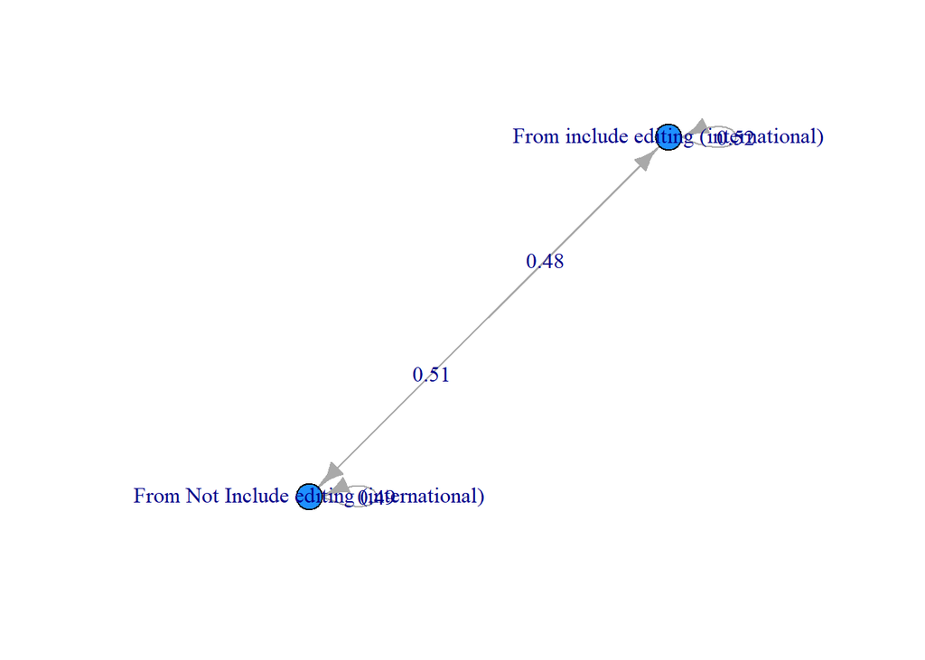

```r
plot(m_object, node.size= 10, layout = matrix(c(1,0,1,0),nrow=2))
```

```r
#Domestic
m2.1.matrix<-c(transition.l$freq[1],transition.l$freq[2],transition.l$freq[4],transition.l$freq[3])
m2.1<-matrix(m2.1.matrix, nrow=2, ncol=2, byrow = T, dimnames = list(n_markov.d.1,n_markov.d))
m_object.1<-new("markovchain",states=n_markov.d.1,byrow=T,transitionMatrix=m2.1, name="State transition")
transition.l
```

| Aspects | change | n | freq |
| --- | --- | --- | --- |
| Include Editing | 0 | 57 | 0.4130435 |
| Include Editing | 1 | 81 | 0.5869565 |
| Not include Editing | 0 | 217 | 0.7161716 |
| Not include Editing | 1 | 86 | 0.2838284 |

```r
m2.1
```

```
##                                     To Include editing (Domestic)
## From include editing (Domestic)                         0.4130435
## From Not Include editing (Domestic)                     0.2838284
##                                     To Not include editing (Domestic)
## From include editing (Domestic)                             0.5869565
## From Not Include editing (Domestic)                         0.7161716
```

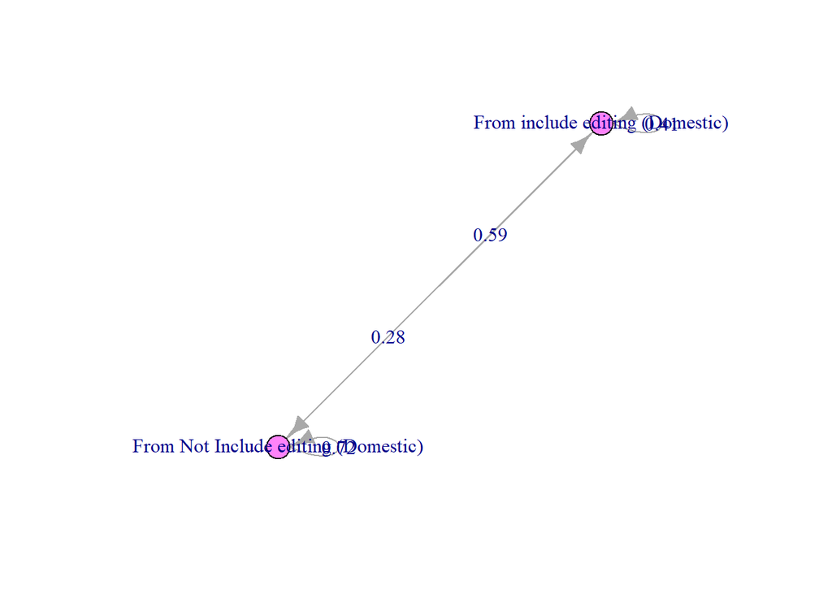

```r
plot(m_object.1, node.size= 10, layout = matrix(c(1,0,1,0),nrow=2))
```

## 4. Words clouds

In this section, we will analyze description section filled out by each tutor and get words clouds for the most frequent n-gram words list (1, 2, 3). For each n-gram words list, we will focus on: 1. Words clouds from all tutors’ comments 2. Words clouds from each tutor and each assignment type. 3. Get top 3 (or 5) most frequent controlled by each tutor and assignment type.

### 4.1 Text mining

We changed the format of the original data set so that it will be easier to do the words clouds analysis. The main idea is for each comments, we break in to n-gram words (1,2,3) and get rid off the word that has no meaning like(the, a, has…). And then, we sort out the top 10-20 frequent words used by each tutor, each assignment, each tutor per each assignment.

### Text mining - stop words

Along with common stop words, we used this set of words: \ e.g, i.e, essay, research, bibliography, annotated, analytical, critical, review, journal, entry, lab, report, literature, review, personal, statement, proposal, research, student, paper, thesis, assignment, draft, appt, 1pm, note, draft, twc, annotated, bibliography, critical, literature, statement, personal, journal, entry, discussed, discussing, review, reviewed

## Text mining - negation, modal, adverbs

We will now first observe the frequency of uncleaned text. It can be seen that Tom Robles dominates in frequency of words. Also analytical essay dominates the observations too. From this, perhaps we should look at the average number of words per observation after it is cleaned instead. Also, it was found that 34.8% of the original words were left after cleaning. Now, for the tutors it can be observed that all the tutors except for Cindy have similar median amount of words per observation. Also, it can be observed that the median number of words per observations controlled by assignment to have some variability between different assignments. On the other hand, when controlled by nationality it can be observed that both groups have a similar median number of words per observation.

```r
#sepearate the each word in description column and get rid of the stop_words,my_stop_words,nma_words
uncleaned_text_tokens <- text_df %>% unnest_tokens(word,text)
uncleaned_text_tokens %>% group_by(tutor) %>% count() # aggregate number of words by tutor
```

| tutor | n |
| --- | --- |
| Cindy Bongard | 483 |
| Colette Granger | 14080 |
| Darcy Litteljohn | 1719 |
| Elisabeth | 6085 |
| Kathyrn Franklin | 15741 |
| Maggie Roberts | 8012 |
| Mina Arakawa | 21091 |
| Paul Raymont | 31048 |
| Tom Robles | 44042 |

```r
uncleaned_text_tokens %>% group_by(assignment) %>% count()  # by assignment
```

| assignment | n |
| --- | --- |
| Analytical.Essay | 62387 |
| Annotated.Bibliography | 2731 |
| Critical.Review | 16587 |
| Journal.Entry | 3562 |
| Lab.Report | 5101 |
| Literature.Review | 4078 |
| Personal.Statement | 1417 |
| Proposal | 6520 |
| Research.Essay | 39918 |

```r
uncleaned_text_tokens %>% group_by(nationality) %>% count() # by nationality
```

| nationality | n |
| --- | --- |
| Domestic | 95055 |
| International | 47246 |

```r
uncleaned_text_count <- uncleaned_text_tokens %>% count()

cleaned_text_tokens <- text_df %>% unnest_tokens(word,text)%>% anti_join(stop_words) %>% anti_join(my_stop_words) %>% anti_join(nma_words)
cleaned_text_count <- cleaned_text_tokens %>% count()

cleaned_text_count/uncleaned_text_count #34.8% from 142288
```

| n |
| --- |
| 0.3480861 |

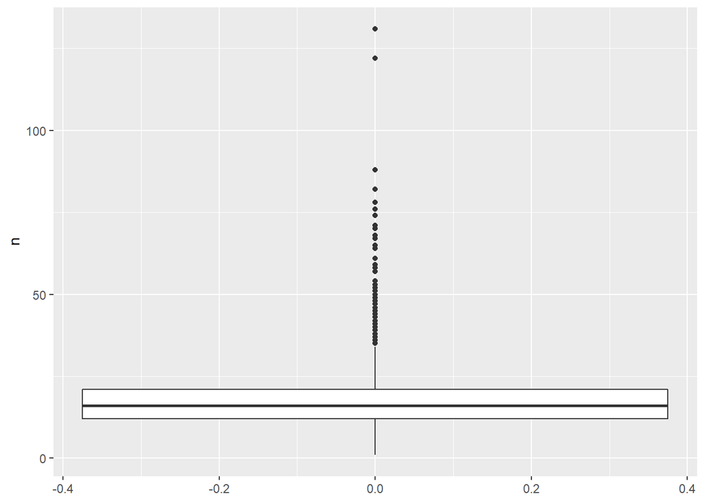

```r
# boxplots of cleaned text per observation
# overall
text_df %>% unnest_tokens(word,text)%>% anti_join(stop_words) %>% anti_join(my_stop_words) %>% anti_join(nma_words) %>% group_by(obs) %>% count() %>% ggplot(aes(y=n)) + geom_boxplot() # non-central (it's fine, but the majority of observations have about 20 meaningful words)
```

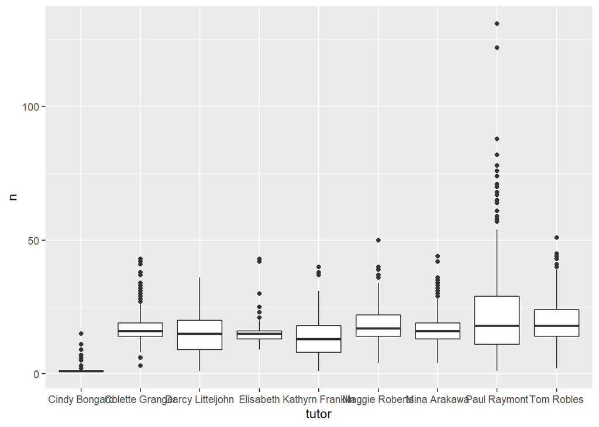

```r
# by tutor
text_df %>% unnest_tokens(word,text)%>% anti_join(stop_words) %>% anti_join(my_stop_words) %>% anti_join(nma_words) %>% group_by(tutor,obs) %>% count() %>% ggplot(aes(x=tutor,y=n)) + geom_boxplot()
```

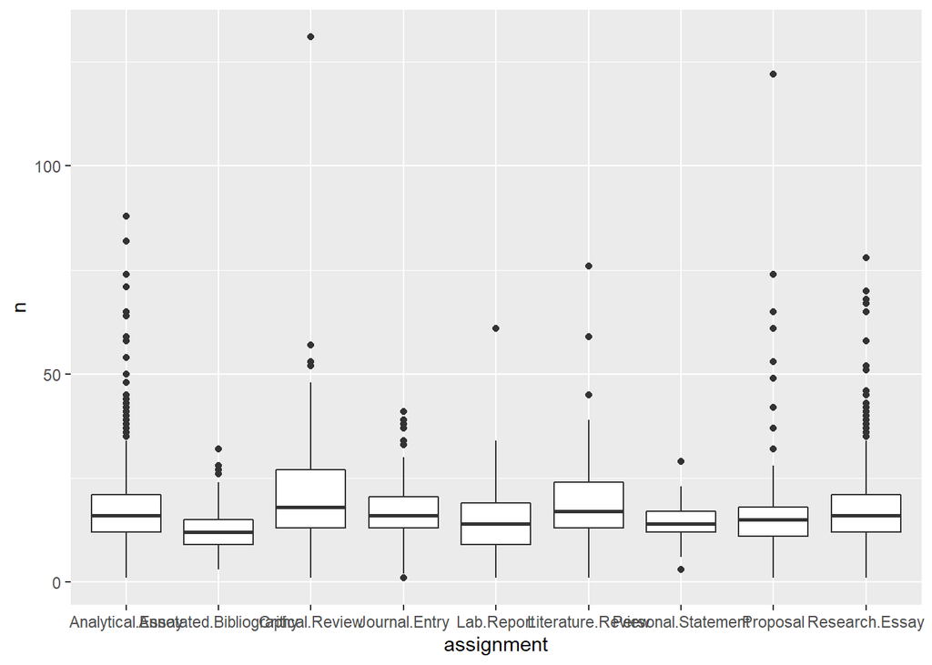

```r
# by assignment
text_df %>% unnest_tokens(word,text)%>% anti_join(stop_words) %>% anti_join(my_stop_words) %>% anti_join(nma_words) %>% group_by(assignment,obs) %>% count() %>% ggplot(aes(x=assignment,y=n)) + geom_boxplot()
```

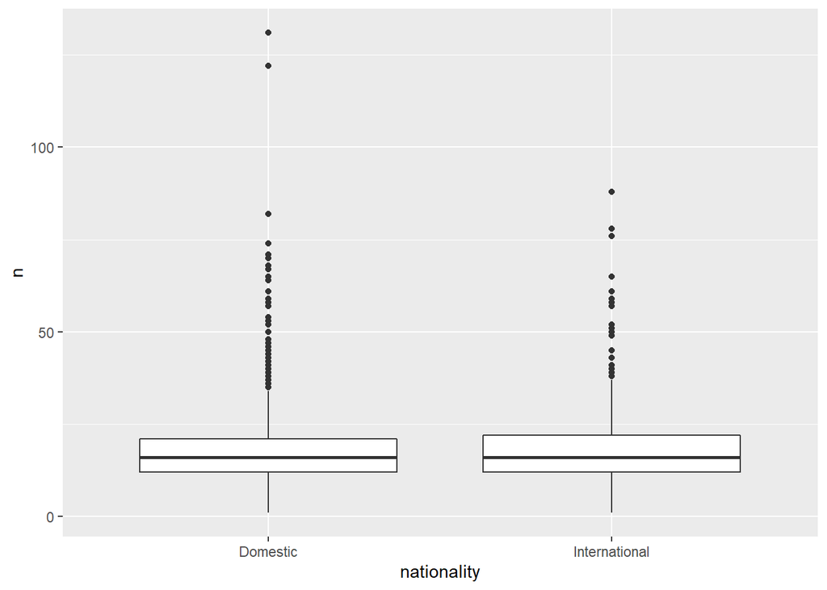

```r
# by nationality
text_df %>% unnest_tokens(word,text)%>% anti_join(stop_words) %>% anti_join(my_stop_words) %>% anti_join(nma_words) %>% group_by(nationality,obs) %>% count() %>% ggplot(aes(x=nationality,y=n)) + geom_boxplot()
```

Source: http://saifmohammad.com/WebPages/SCL.html#NMA

Negation words such as ‘no’ and ‘cannot’, modal words such as ‘would’ve’ and ‘could’, and adverbs such as ‘quite’ and ‘less’ are words that provide sentiment to the verbs it is describing. We decided to remove these words because tutor comments are supposed to be objective.

```r
#####note: Asher Ghaffar did not write any descriptions, so the text mining get rid of her entry
text_tokens <- text_df %>% unnest_tokens(word, text) %>% anti_join(stop_words) %>% anti_join(my_stop_words) %>% anti_join(nma_words)
# remove NA entries
text_tokens<-text_tokens %>%na.omit()
#word stemming (e.g layers,layer -> layer)
text_tokens<-text_tokens %>%
      mutate_at("word", funs(wordStem((.), language="en")))
```

```r
#cleans all numeric numbers in description
text_tokens <- text_tokens[-grep("\\b\\d+\\b", text_tokens$word),] # cleans the text already

# For loop to get all the top words for the word cloud
```

### 4.2 (1-gram) All comments: Words clouds from all tutors’ comments

```r
# TODO: apply some sort of scaling so that Tom's entries aren't as influential.
text_tokens %>% count(word,sort=TRUE) %>% mutate(prop = prop.table(n)) %>% slice(1:10)
```

| word | n | prop |
| --- | --- | --- |
| write | 859 | 0.017585522 |
| feedback | 655 | 0.013409217 |
| goal | 568 | 0.011628145 |
| discuss | 549 | 0.011239175 |
| research | 534 | 0.010932094 |
| argument | 518 | 0.010604541 |
| analysi | 500 | 0.010236043 |
| idea | 499 | 0.010215571 |
| question | 492 | 0.010072266 |
| import | 478 | 0.009785657 |

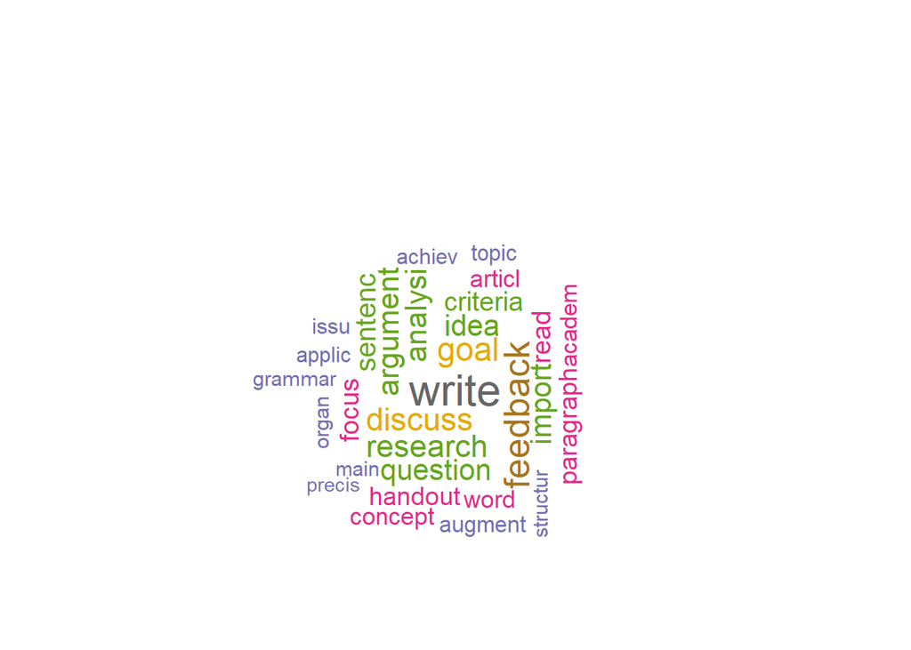

```r
par(mar = rep(0, 4))
layout(matrix(c(1, 2), nrow=2), heights=c(1, 4))
plot.new()
text_tokens %>% count(word,sort=TRUE) %>% with(wordcloud(word, n, max.words = 30, scale = c(2,0.5),
           random.order=FALSE, rot.per=0.35,
          colors=brewer.pal(8, "Dark2"), main="Title"))
```

*Overall 1-gram wordcloud*

### (1-gram) by Each Tutor: Words clouds from each tutor

For each tutor, they have differnt frequent words they would like to use, when they fill up the description section.

```r
tutor_first_name <- c("Tom Robles","Paul Raymont","Kathyrn Franklin","Colette Granger","Maggie Roberts","Darcy Litteljohn","Mina Arakawa","Cindy Bongard","Elisabeth")
#unique_tutors <- levels(newdata$Tutor)
unique_assignment <- levels(factor(newdata$Assignment_type))
```

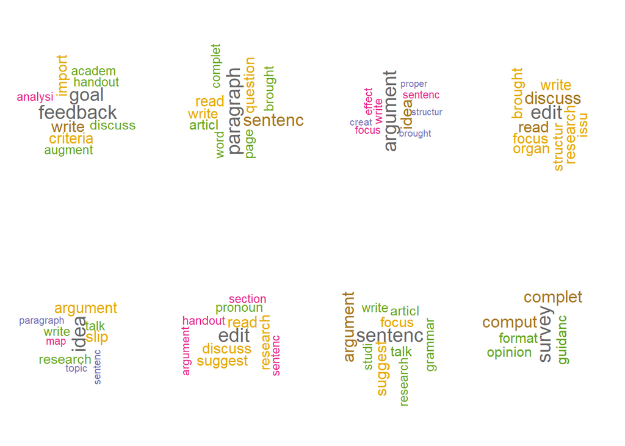

```r
####

tutor_token <- list()
#levels(text_tokens$tutor) = with(text_tokens,sapply(levels(tutor),tutor_relevel))
ut<-unique(text_tokens$tutor)
####
par(mfrow=c(2,4))
for(i in 1:9) {
  # tutors
 temp_tut <- text_tokens %>% filter(tutor == ut[i]) %>% count(word,sort=TRUE) %>% mutate(prop = prop.table(n))
  tutor_token[[i]] <- temp_tut %>% slice(1:5) # select top 5 rows
  # plot shit
    # tutor word clouds
  par(mar = rep(0, 4))
  temp_tut %>% with(wordcloud(word, n, max.words = 10, scale = c(2,0.5),
           random.order=FALSE, rot.per=0.35,
          colors=brewer.pal(8, "Dark2"), main="Title"))
}
```

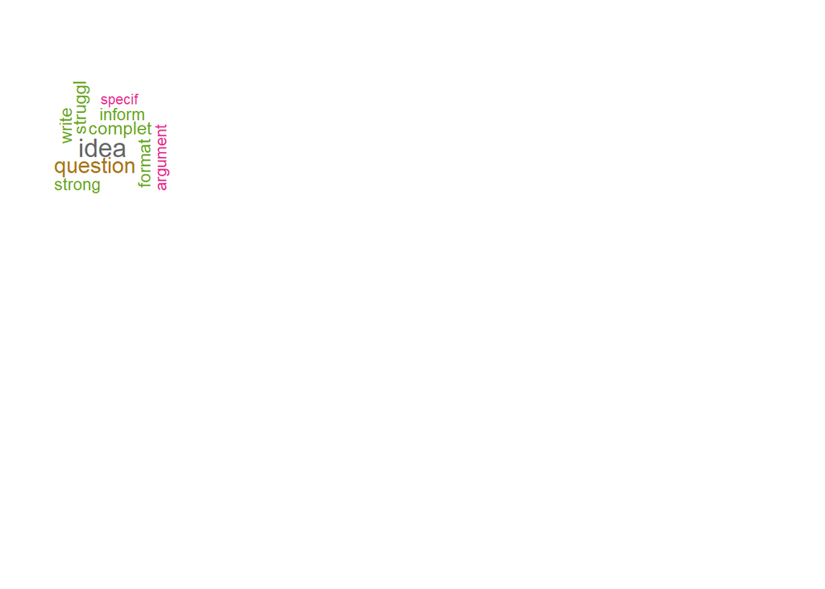

```r
par(mfrow=c(1,1))
```

```r
# use these to see tokens side by side
# every 1st column - word
# every 2nd column - count in n
# every 3rd column - proportion
tutor_tokens <- tutor_token %>% bind_cols
tokens.tutor <- tutor_tokens[,seq(1,ncol(tutor_tokens),by=3)]
tokens.tutor.prop <- tutor_tokens[,seq(3,ncol(tutor_tokens),by=3)]
tokens.tutor.n <- tutor_tokens[,seq(2,ncol(tutor_tokens),by=3)]
colnames(tokens.tutor) = tutor_first_name
colnames(tokens.tutor.prop) = tutor_first_name
colnames(tokens.tutor.n) = tutor_first_name
```

Words

```r
tokens.tutor
```

| Tom Robles | Paul Raymont | Kathyrn Franklin | Colette Granger | Maggie Roberts | Darcy Litteljohn | Mina Arakawa | Cindy Bongard | Elisabeth |
| --- | --- | --- | --- | --- | --- | --- | --- | --- |
| feedback | paragraph | argument | edit | idea | edit | sentenc | survey | idea |
| goal | sentenc | idea | discuss | slip | read | argument | complet | question |
| write | read | write | read | argument | discuss | suggest | comput | complet |
| criteria | question | effect | research | research | suggest | focus | format | struggl |
| import | write | focus | write | talk | research | talk | guidanc | write |

```r
#print(xtable(tokens.tutor), scalebox='0.7', floating=FALSE)
#print(xtable(tokens.tutor.prop), scalebox='0.7', floating=FALSE)
#print(xtable(tokens.tutor.n), scalebox='0.7', floating=FALSE)
```

Proportion

```r
tokens.tutor.prop
```

| Tom Robles | Paul Raymont | Kathyrn Franklin | Colette Granger | Maggie Roberts | Darcy Litteljohn | Mina Arakawa | Cindy Bongard | Elisabeth |
| --- | --- | --- | --- | --- | --- | --- | --- | --- |
| 0.04126433 | 0.01602031 | 0.03650935 | 0.014213198 | 0.02548883 | 0.02576112 | 0.02036288 | 0.04347826 | 0.02549575 |
| 0.03799931 | 0.01374420 | 0.02782725 | 0.011979695 | 0.01850559 | 0.01873536 | 0.01618588 | 0.03478261 | 0.02077432 |
| 0.03153873 | 0.01120546 | 0.01758682 | 0.010761421 | 0.01815642 | 0.01756440 | 0.01488056 | 0.03478261 | 0.01510859 |
| 0.02924627 | 0.01076775 | 0.01536064 | 0.009949239 | 0.01501397 | 0.01756440 | 0.01305313 | 0.02608696 | 0.01463645 |
| 0.02799583 | 0.01015495 | 0.01469279 | 0.009949239 | 0.01361732 | 0.01639344 | 0.01226994 | 0.02608696 | 0.01416431 |

Frequency

```r
tokens.tutor.n
```

| Tom Robles | Paul Raymont | Kathyrn Franklin | Colette Granger | Maggie Roberts | Darcy Litteljohn | Mina Arakawa | Cindy Bongard | Elisabeth |
| --- | --- | --- | --- | --- | --- | --- | --- | --- |
| 594 | 183 | 164 | 70 | 73 | 22 | 156 | 5 | 54 |
| 547 | 157 | 125 | 59 | 53 | 16 | 124 | 4 | 44 |
| 454 | 128 | 79 | 53 | 52 | 15 | 114 | 4 | 32 |
| 421 | 123 | 69 | 49 | 43 | 15 | 100 | 3 | 31 |
| 403 | 116 | 66 | 49 | 39 | 14 | 94 | 3 | 30 |

```r
# print of latex tables
# 1 grams by tutor :)
#print(xtable(tokens.tutor), scalebox='0.7', floating=FALSE)
#print(xtable(tokens.tutor.prop), scalebox='0.7', floating=FALSE)
#print(xtable(tokens.tutor.n), scalebox='0.7', floating=FALSE)
```

### (1-gram) by Each Assignment type: Words clouds from each assignment type.

We can see a pattern that, students have different concerns when they need help in different assignment types.

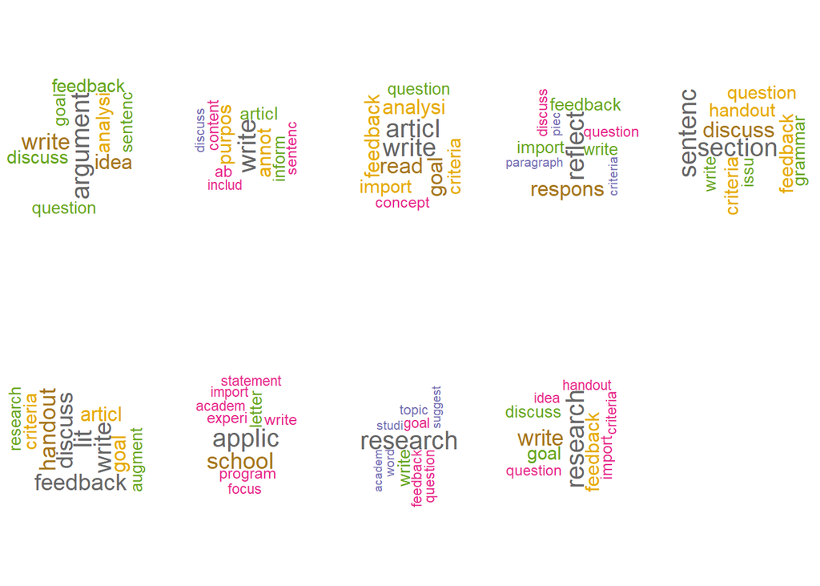

```r
assignment_tokens <- list()

par(mfrow=c(2,5))
  for(j in 1:9) {
    # assignments
    temp_assign <- text_tokens %>% filter(assignment == unique_assignment[j]) %>% count(word,sort=TRUE) %>% mutate(prop = prop.table(n))
    assignment_tokens[[j]] <- temp_assign %>% slice(1:5)
  # plot shit
    # assignment word clouds
  par(mar = rep(0, 4))
  temp_assign %>% with(wordcloud(word, n, max.words = 10, scale = c(2,0.5),
           random.order=FALSE, rot.per=0.35,
          colors=brewer.pal(8, "Dark2"), main="Title"))
  }
par(mfrow=c(1,1))
```

```r
tokens_assign <- assignment_tokens %>% bind_cols

tokens.assign <- tokens_assign[,seq(1,ncol(tokens_assign),by=3)]
tokens.assign.prop <- tokens_assign[,seq(3,ncol(tokens_assign),by=3)]
tokens.assign.n <- tokens_assign[,seq(2,ncol(tokens_assign),by=3)]
colnames(tokens.assign) = unique_assignment
colnames(tokens.assign.prop) = unique_assignment
colnames(tokens.assign.n) = unique_assignment
```

*Word Cloud plots by assignment in order* *(Top Row) Analytical.Essay, Annotated.Bibliography, Critical.Review, Journal.Entry, Lab.Report* *(Bottom Row) Literature.Review, Personal.Statement, Proposal, Research.Essay*

Words

```r
tokens.assign[6:9]
```

| Literature.Review | Personal.Statement | Proposal | Research.Essay |
| --- | --- | --- | --- |
| lit | applic | research | research |
| write | school | write | write |
| discuss | letter | goal | feedback |
| feedback | experi | feedback | goal |
| handout | program | question | discuss |

Proportion

```r
tokens.assign.prop
```

| Analytical.Essay | Annotated.Bibliography | Critical.Review | Journal.Entry | Lab.Report | Literature.Review | Personal.Statement | Proposal | Research.Essay |
| --- | --- | --- | --- | --- | --- | --- | --- | --- |
| 0.01772540 | 0.03110599 | 0.02027504 | 0.03208138 | 0.02255639 | 0.01849112 | 0.03112033 | 0.03058929 | 0.02410167 |
| 0.01545172 | 0.02073733 | 0.02009873 | 0.02425665 | 0.02255639 | 0.01701183 | 0.02697095 | 0.01754386 | 0.01986561 |
| 0.01350285 | 0.02073733 | 0.01657264 | 0.01877934 | 0.01792944 | 0.01627219 | 0.01659751 | 0.01214575 | 0.01665206 |
| 0.01201800 | 0.01843318 | 0.01569111 | 0.01799687 | 0.01561596 | 0.01627219 | 0.01452282 | 0.01169591 | 0.01489921 |
| 0.01071876 | 0.01612903 | 0.01480959 | 0.01799687 | 0.01503759 | 0.01553254 | 0.01452282 | 0.01169591 | 0.01256208 |

Frequency

```r
tokens.assign.n
```

| Analytical.Essay | Annotated.Bibliography | Critical.Review | Journal.Entry | Lab.Report | Literature.Review | Personal.Statement | Proposal | Research.Essay |
| --- | --- | --- | --- | --- | --- | --- | --- | --- |
| 382 | 27 | 115 | 41 | 39 | 25 | 15 | 68 | 330 |
| 333 | 18 | 114 | 31 | 39 | 23 | 13 | 39 | 272 |
| 291 | 18 | 94 | 24 | 31 | 22 | 8 | 27 | 228 |
| 259 | 16 | 89 | 23 | 27 | 22 | 7 | 26 | 204 |
| 231 | 14 | 84 | 23 | 26 | 21 | 7 | 26 | 172 |

```r
# print of latex tables
# 1 grams by tutor :)
#print(xtable(tokens.assign), scalebox='0.7', floating=FALSE)
#print(xtable(tokens.assign.prop), scalebox='0.7', floating=FALSE)
#print(xtable(tokens.assign.n), scalebox='0.7', floating=FALSE)
```

### (1-gram) by student nationality: Get frequent 1-gram words list from nationality

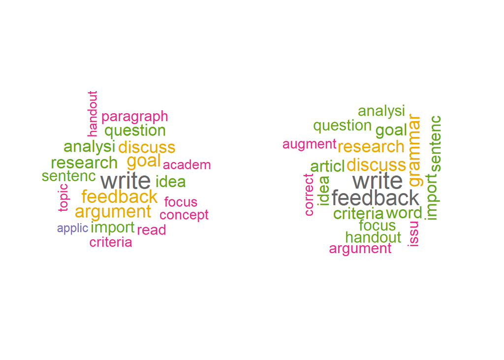

```r
nat_tokens <- list()
par(mfrow=c(1,2))
  for(j in 1:2) {
    # assignments
    temp_nat <- text_tokens %>% filter(nationality == levels(newdata$Nationality)[j]) %>% count(word,sort=TRUE) %>% mutate(prop = prop.table(n))
    nat_tokens[[j]] <- temp_nat %>% slice(1:10)
    par(mar = rep(0, 4))
          #tutor_bigram_wc.png
      temp_nat %>% with(wordcloud(word, n, max.words = 20, scale = c(2,0.5),
           random.order=FALSE, rot.per=0.35,
          colors=brewer.pal(8, "Dark2"), main="Title"))

  }
```

```r
par(mfrow=c(1,1))


tokens_nat <- nat_tokens %>% bind_cols

tokens.nat <- tokens_nat[,seq(1,ncol(tokens_nat),by=3)]
tokens.nat.prop <- tokens_nat[,seq(3,ncol(tokens_nat),by=3)]
tokens.nat.n <- tokens_nat[,seq(2,ncol(tokens_nat),by=3)]
colnames(tokens.nat) = levels(newdata$Nationality)
colnames(tokens.nat.prop) = levels(newdata$Nationality)
colnames(tokens.nat.n) = levels(newdata$Nationality)
```

*Word Cloud plots by nationality in order* *Domestic students, International students*

Words

```r
tokens.nat
```

| Domestic | International |
| --- | --- |
| write | write |
| feedback | feedback |
| goal | grammar |
| argument | discuss |
| discuss | research |
| research | criteria |
| analysi | word |
| idea | goal |
| question | import |
| import | articl |

Proportion

```r
tokens.nat.prop
```

| Domestic | International |
| --- | --- |
| 0.018008345 | 0.016737432 |
| 0.012762302 | 0.014706787 |
| 0.012424837 | 0.011445450 |
| 0.011872622 | 0.011076241 |
| 0.011320407 | 0.010583964 |
| 0.011105657 | 0.010276291 |
| 0.010921585 | 0.010091687 |
| 0.010645478 | 0.010030152 |
| 0.010584121 | 0.010030152 |
| 0.009663762 | 0.009845548 |

Frequency

```r
tokens.nat.n
```

| Domestic | International |
| --- | --- |
| 587 | 272 |
| 416 | 239 |
| 405 | 186 |
| 387 | 180 |
| 369 | 172 |
| 362 | 167 |
| 356 | 164 |
| 347 | 163 |
| 345 | 163 |
| 315 | 160 |

```r
# print of latex tables
# 1 grams by nationality :)
#print(xtable(tokens.nat), scalebox='0.7', floating=FALSE)
#print(xtable(tokens.nat.prop), scalebox='0.7', floating=FALSE)
#print(xtable(tokens.nat.n), scalebox='0.7', floating=FALSE)
```

### 4.3 (2-gram) All comments

```r
# Question: Does it make sense to stem n-grams where n > 1 ??
# the token to look for 2 words.
bigram_tokens <- text_df %>% unnest_tokens(bigram, text, token = "ngrams", n = 2)
bigram_tokens <- bigram_tokens %>%
    separate(bigram, c("word1", "word2"), sep = " ") %>%
    filter(!word1 %in% stop_words$word,
           !word2 %in% stop_words$word) %>%
    filter(!word1 %in% my_stop_words$word,
           !word2 %in% my_stop_words$word) %>%
    filter(!word1 %in% nma_words$word,
           !word2 %in% nma_words$word)

#Remove trailing and leading spaces and extra internal whitespace with one gsub call
bigram_tokens$word1 <- gsub("\\s+","",bigram_tokens$word1)
bigram_tokens$word2 <- gsub("\\s+","",bigram_tokens$word2)
bigram_tokens <- bigram_tokens %>% na.omit() # remove NA entries
# grep returns integer or integer(0) <- vector of length 0

#word stemming (e.g layers,layer -> layer)
bigram_tokens<-bigram_tokens %>%
      mutate_at("word1", funs(wordStem((.), language="en"))) %>% mutate_at("word2", funs(wordStem((.), language="en")))

#cleans all numeric numbers in description
bigram_tokens <- bigram_tokens[-grep("\\b\\d+\\b", bigram_tokens$word1),] #word1
bigram_tokens <- bigram_tokens[-grep("\\b\\d+\\b", bigram_tokens$word2),] #word2

#unite bigram with space
bigrams_united <- bigram_tokens %>% unite(bigram, word1, word2,sep=" ")
```

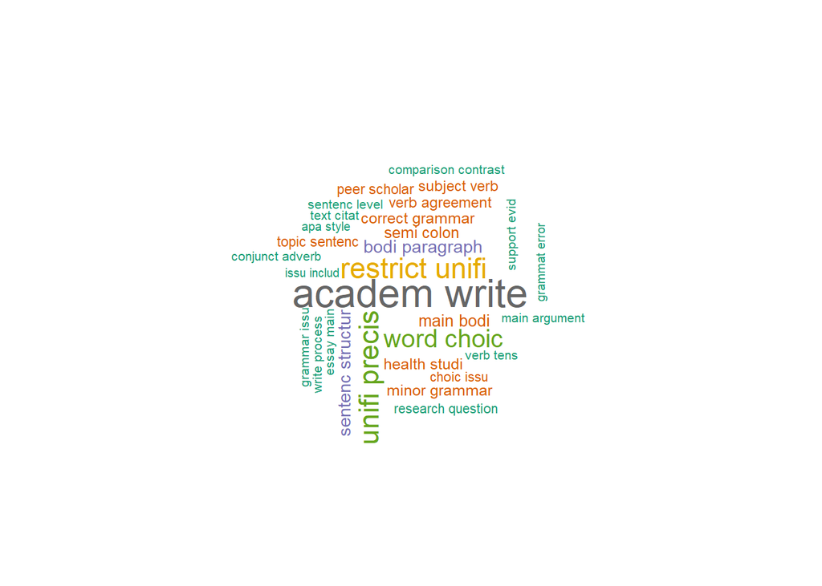

```r
par(mar = rep(0, 4))
bigrams_united %>% count(bigram,sort=TRUE) %>% with(wordcloud(bigram, n, max.words = 30, scale = c(2,0.5),
           random.order=FALSE, rot.per=0.35,
          colors=brewer.pal(8, "Dark2"), main="Title"))
```

Words, Proportion & Frequency

```r
# TODO: same as previous one for unigram how do we apply a sort of weighting in order to reduce Tom's influence??
bigrams_united %>% count(bigram,sort=TRUE) %>% mutate(prop=prop.table(n)) %>% slice(1:10)
```

| bigram | n | prop |
| --- | --- | --- |
| academ write | 287 | 0.023403735 |
| restrict unifi | 184 | 0.015004485 |
| unifi precis | 178 | 0.014515208 |
| word choic | 147 | 0.011987279 |
| sentenc structur | 76 | 0.006197505 |
| bodi paragraph | 75 | 0.006115959 |
| main bodi | 66 | 0.005382044 |
| semi colon | 62 | 0.005055859 |
| correct grammar | 55 | 0.004485036 |
| health studi | 54 | 0.004403490 |

### (2-gram) by Each Tutor

For each tutor, they have differnt frequent words they would like to use, when they fill up the description section.

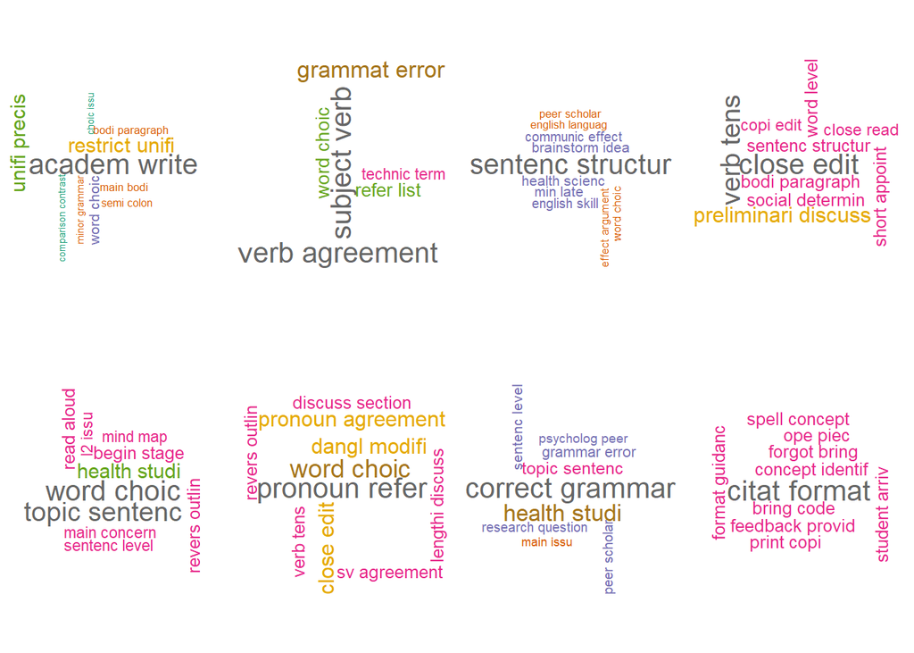

```r
tutor_bigrams <- list()
assignment_bigrams <- list()
nat_bigrams <- list()
tutor_bc_plt <- list()
####
mixed_count <- 1

par(mfrow=c(2,4))
for(i in 1:9) {
  # tutors
 temp_tut <- bigrams_united %>% filter(tutor == ut[i]) %>% count(bigram,sort=TRUE) %>% mutate(prop = prop.table(n))
  tutor_bigrams[[i]] <- temp_tut %>% slice(1:5) # select top 5 rows
  par(mar = rep(0, 4))
  temp_tut %>% with(wordcloud(bigram, n, max.words = 10, scale = c(2,0.5),
           random.order=FALSE, rot.per=0.35,
          colors=brewer.pal(8, "Dark2"), main="Title"))
}
```

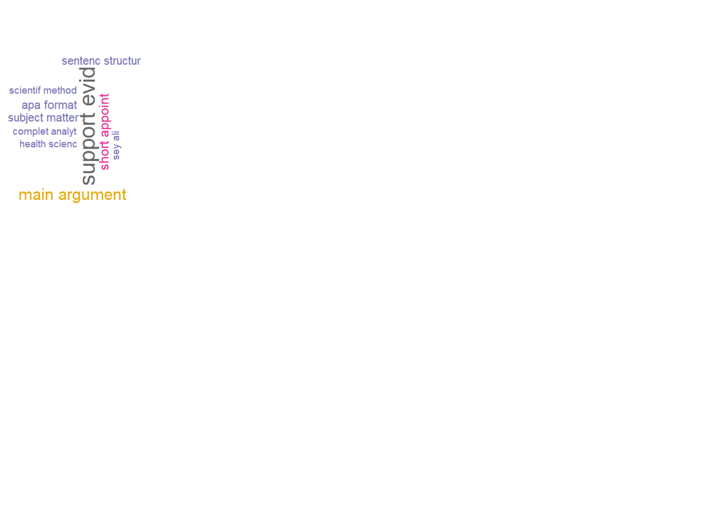

```r
par(mfrow=c(1,1))
```

```r
# use this to see the top 5 words side by side
tutor_bigrams <- tutor_bigrams %>% bind_cols
bigrams.tutor <- tutor_bigrams[,seq(1,ncol(tutor_bigrams),by=3)]
bigrams.tutor.n <- tutor_bigrams[,seq(2,ncol(tutor_bigrams),by=3)]
bigrams.tutor.prop <- tutor_bigrams[,seq(3,ncol(tutor_bigrams),by=3)]
colnames(bigrams.tutor) <- tutor_first_name
colnames(bigrams.tutor.prop) <- tutor_first_name
```

Words

```r
bigrams.tutor[5:9]
```

| Maggie Roberts | Darcy Litteljohn | Mina Arakawa | Cindy Bongard | Elisabeth |
| --- | --- | --- | --- | --- |
| word choic | pronoun refer | correct grammar | citat format | support evid |
| topic sentenc | word choic | health studi | bring code | main argument |
| health studi | close edit | sentenc structur | bring print | short appoint |
| begin stage | dangl modifi | topic sentenc | brought form | apa format |
| read aloud | pronoun agreement | grammar error | complet survey | sentenc structur |

Proportion

```r
bigrams.tutor.prop
```

| Tom Robles | Paul Raymont | Kathyrn Franklin | Colette Granger | Maggie Roberts | Darcy Litteljohn | Mina Arakawa | Cindy Bongard | Elisabeth |
| --- | --- | --- | --- | --- | --- | --- | --- | --- |
| 0.08690330 | 0.008743523 | 0.030973451 | 0.009456265 | 0.013495277 | 0.01562500 | 0.025390625 | 0.06896552 | 0.020676692 |
| 0.05507956 | 0.008743523 | 0.009955752 | 0.008668243 | 0.012145749 | 0.01302083 | 0.019531250 | 0.03448276 | 0.013157895 |
| 0.05324357 | 0.006800518 | 0.009955752 | 0.006304177 | 0.008097166 | 0.01041667 | 0.011718750 | 0.03448276 | 0.009398496 |
| 0.02906977 | 0.005505181 | 0.009955752 | 0.004728132 | 0.006747638 | 0.01041667 | 0.011718750 | 0.03448276 | 0.007518797 |
| 0.01866585 | 0.004857513 | 0.008849558 | 0.004728132 | 0.006747638 | 0.01041667 | 0.008789062 | 0.03448276 | 0.007518797 |

Frequency

```r
bigrams.tutor.n
```

| n | n1 | n2 | n3 | n4 | n5 | n6 | n7 | n8 |
| --- | --- | --- | --- | --- | --- | --- | --- | --- |
| 284 | 27 | 28 | 12 | 10 | 6 | 52 | 2 | 11 |
| 180 | 27 | 9 | 11 | 9 | 5 | 40 | 1 | 7 |
| 174 | 21 | 9 | 8 | 6 | 4 | 24 | 1 | 5 |
| 95 | 17 | 9 | 6 | 5 | 4 | 24 | 1 | 4 |
| 61 | 15 | 8 | 6 | 5 | 4 | 18 | 1 | 4 |

```r
#print(xtable(bigrams.tutor[,1:4]), scalebox='0.7', floating=FALSE)
#print(xtable(bigrams.tutor[,4:8]), scalebox='0.7', floating=FALSE)
#print(xtable(bigrams.tutor.prop[,1:4]), scalebox='0.7', floating=FALSE)
#print(xtable(bigrams.tutor.prop[,4:8]), scalebox='0.7', floating=FALSE)
```

### (2-gram) by Each Assignment type

We can see a pattern that, students have different concerns when they need help in different assignment types.

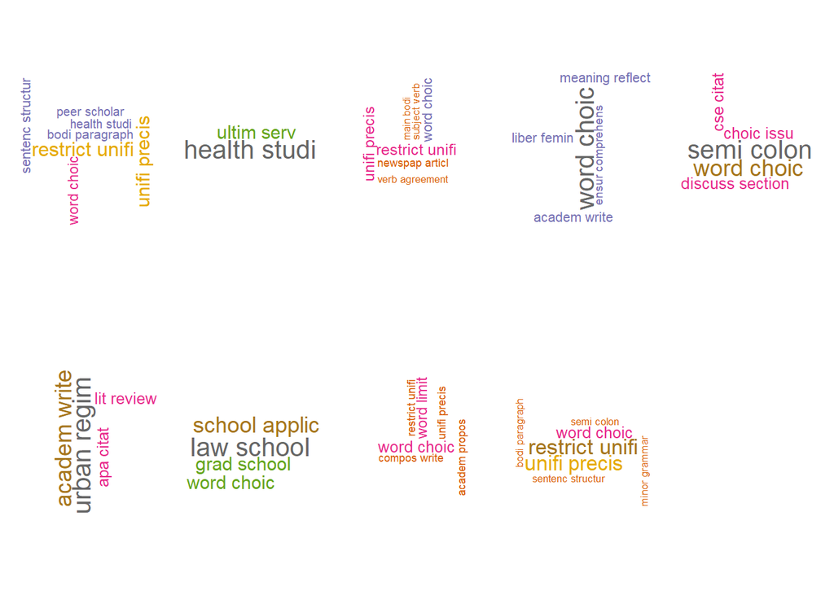

```r
length.as=length(unique_assignment)
par(mfrow=c(2,5))
  for(j in 1:length.as) {
    # assignments
    temp_assign <- bigrams_united %>% filter(assignment == unique_assignment[j]) %>% count(bigram,sort=TRUE) %>% mutate(prop = prop.table(n))
    assignment_bigrams[[j]] <- temp_assign %>% slice(1:5)
    par(mar = rep(0, 4))
      temp_assign %>% with(wordcloud(bigram, n, max.words = 8, scale = c(2,0.5),
           random.order=FALSE, rot.per=0.35,
          colors=brewer.pal(8, "Dark2"), main="Title"))
  }
par(mfrow=c(1,1))
```

```r
assign_bigrams <- assignment_bigrams %>% bind_cols


bigrams.assign <- assign_bigrams[,seq(1,ncol(assign_bigrams),by=3)]
bigrams.assign.prop <- assign_bigrams[,seq(3,ncol(assign_bigrams),by=3)]
bigrams.assign.n <- assign_bigrams[,seq(2,ncol(assign_bigrams),by=3)]
colnames(bigrams.assign) <- unique_assignment
colnames(bigrams.assign.prop) <- unique_assignment
```

*Word Cloud plots by assignment in order* *(Top Row) Analytical.Essay, Annotated.Bibliography, Critical.Review, Journal.Entry, Lab.Report* *(Bottom Row) Literature.Review, Personal.Statement, Proposal, Research.Essay*

Word

```r
bigrams.assign[5:9]
```

| Lab.Report | Literature.Review | Personal.Statement | Proposal | Research.Essay |
| --- | --- | --- | --- | --- |
| semi colon | urban regim | law school | academ write | academ write |
| minor grammar | academ write | school applic | research question | restrict unifi |
| word choic | conjunct adverb | grad school | word choic | unifi precis |
| result section | semi colon | word choic | word limit | word choic |
| choic issu | apa citat | correct word | academ propos | minor grammar |

Proportion

```r
bigrams.assign.prop
```

| Analytical.Essay | Annotated.Bibliography | Critical.Review | Journal.Entry | Lab.Report | Literature.Review | Personal.Statement | Proposal | Research.Essay |
| --- | --- | --- | --- | --- | --- | --- | --- | --- |
| 0.021095485 | 0.02702703 | 0.032490975 | 0.03254438 | 0.02494802 | 0.018808777 | 0.04273504 | 0.021238938 | 0.030268089 |
| 0.014248705 | 0.02162162 | 0.015162455 | 0.02662722 | 0.02079002 | 0.015673981 | 0.03418803 | 0.014159292 | 0.023061401 |
| 0.013693560 | 0.01621622 | 0.015162455 | 0.02071006 | 0.02079002 | 0.012539185 | 0.02564103 | 0.010619469 | 0.022196598 |
| 0.007957069 | 0.01621622 | 0.011552347 | 0.01183432 | 0.01871102 | 0.012539185 | 0.02564103 | 0.008849558 | 0.014701643 |
| 0.007401925 | 0.01621622 | 0.007220217 | 0.01183432 | 0.01247401 | 0.009404389 | 0.01709402 | 0.005309735 | 0.006630153 |

Frequency

```r
bigrams.assign.n
```

| n | n1 | n2 | n3 | n4 | n5 | n6 | n7 | n8 |
| --- | --- | --- | --- | --- | --- | --- | --- | --- |
| 114 | 5 | 45 | 11 | 12 | 6 | 5 | 12 | 105 |
| 77 | 4 | 21 | 9 | 10 | 5 | 4 | 8 | 80 |
| 74 | 3 | 21 | 7 | 10 | 4 | 3 | 6 | 77 |
| 43 | 3 | 16 | 4 | 9 | 4 | 3 | 5 | 51 |
| 40 | 3 | 10 | 4 | 6 | 3 | 2 | 3 | 23 |

```r
#print(xtable(bigrams.assign[,1:5]),  scalebox='0.7', floating=FALSE)
#print(xtable(bigrams.assign[,5:9]), scalebox='0.7', floating=FALSE)
#print(xtable(bigrams.assign.prop), scalebox='0.7', floating=FALSE)
#print(xtable(bigrams.assign.n),  scalebox='0.7', floating=FALSE)
```

### (2-gram) by student nationality: Get frequent bigrams list from nationality

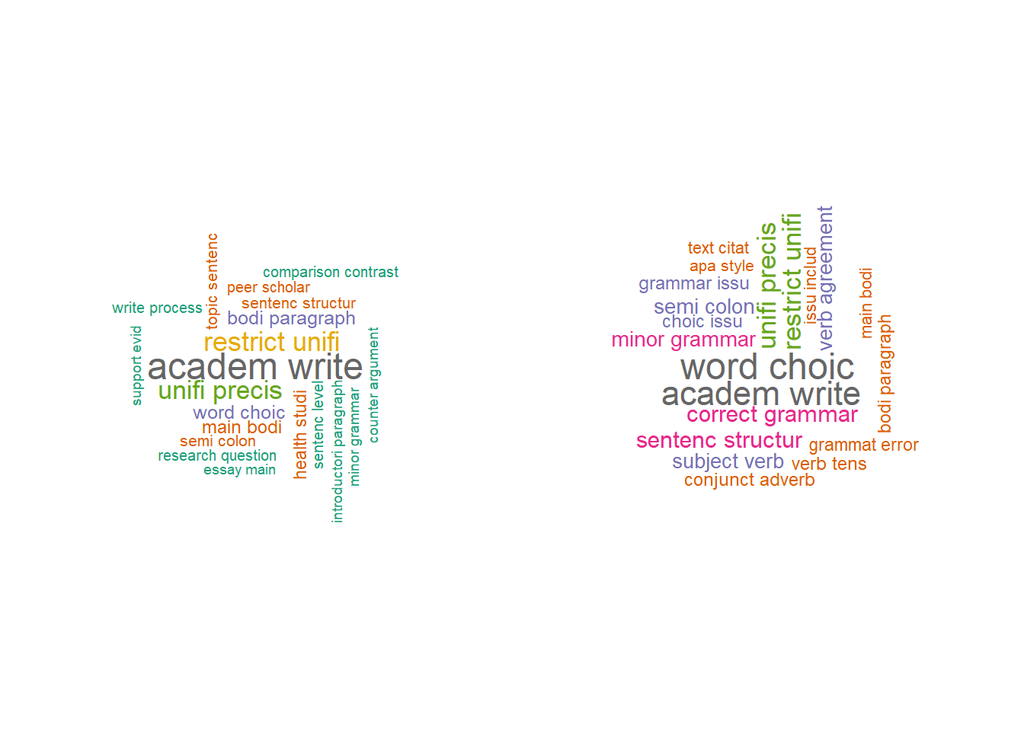

```r
nat <- c("Domestic","International")
par(mfrow=c(1,2))
  for(j in 1:2) {
    # assignments
    temp_nat <- bigrams_united %>% filter(nationality == nat[j]) %>% count(bigram,sort=TRUE) %>% mutate(prop = prop.table(n))
    nat_bigrams[[j]] <- temp_nat  %>% slice(1:10)
    par(mar = rep(0, 4))
      temp_nat %>% with(wordcloud(bigram, n, max.words = 20, scale = c(1.5,0.5),
           random.order=FALSE, rot.per=0.35,
          colors=brewer.pal(8, "Dark2"), main="Title"))
  }
```

```r
par(mfrow=c(1,1))
nationality_bigrams <- nat_bigrams %>% bind_cols
bigrams.nat <- nationality_bigrams[,seq(1,ncol(nationality_bigrams),by=3)]
bigrams.nat.prop <- nationality_bigrams[,seq(3,ncol(nationality_bigrams),by=3)]
bigrams.nat.n <- nationality_bigrams[,seq(2,ncol(nationality_bigrams),by=3)]
colnames(bigrams.nat) <- levels(newdata$Nationality)
colnames(bigrams.nat.prop) <- levels(newdata$Nationality)
colnames(bigrams.nat.n) <- levels(newdata$Nationality)
```

*Word Cloud plots by nationality in order* *Domestic students, International students*

Words

```r
bigrams.nat
```

| Domestic | International |
| --- | --- |
| academ write | word choic |
| restrict unifi | academ write |
| unifi precis | restrict unifi |
| word choic | unifi precis |
| bodi paragraph | correct grammar |
| main bodi | sentenc structur |
| health studi | minor grammar |
| sentenc structur | semi colon |
| topic sentenc | verb agreement |
| semi colon | subject verb |

Proportion

```r
bigrams.nat.prop
```

| Domestic | International |
| --- | --- |
| 0.026220502 | 0.020451340 |
| 0.016481458 | 0.018100611 |
| 0.015857161 | 0.012223789 |
| 0.007491572 | 0.011988717 |
| 0.007116993 | 0.009637988 |
| 0.006242977 | 0.009637988 |
| 0.005743539 | 0.007757405 |
| 0.004370084 | 0.007522332 |
| 0.003870646 | 0.007052186 |
| 0.003745786 | 0.006817113 |

Frequency

```r
bigrams.nat.n
```

| Domestic | International |
| --- | --- |
| 210 | 87 |
| 132 | 77 |
| 127 | 52 |
| 60 | 51 |
| 57 | 41 |
| 50 | 41 |
| 46 | 33 |
| 35 | 32 |
| 31 | 30 |
| 30 | 29 |

```r
#print(xtable(bigrams.nat),  scalebox='0.7', floating=FALSE)
#print(xtable(bigrams.nat.prop), scalebox='0.7', floating=FALSE)
#print(xtable(bigrams.nat.n),  scalebox='0.7', floating=FALSE)
```

### Text mining summary

```r
num_words <- text_tokens %>% count(tutor)
num_obs <- newdata %>% group_by(Tutor) %>% summarize(count=n()) %>% mutate(prop = prop.table(count))
num_obs
```

| Tutor | count | prop |
| --- | --- | --- |
| Asher Ghaffar | 185 | 0.04747241 |
| Cindy Bongard | 149 | 0.03823454 |
| Colette Granger | 457 | 0.11726969 |
| Darcy Litteljohn | 59 | 0.01513985 |
| Elisabeth | 138 | 0.03541186 |
| Kathyrn Franklin | 329 | 0.08442392 |
| Maggie Roberts | 237 | 0.06081601 |
| Mina Arakawa | 635 | 0.16294586 |
| Paul Raymont | 699 | 0.17936875 |
| Tom Robles | 1009 | 0.25891712 |

Average words per tutor

```r
num_obs<-num_obs %>% filter(Tutor!="Asher Ghaffar")
levels(droplevels(num_words$tutor))
```

```
## [1] "Cindy Bongard"    "Colette Granger"  "Darcy Litteljohn" "Elisabeth"
## [5] "Kathyrn Franklin" "Maggie Roberts"   "Mina Arakawa"     "Paul Raymont"
## [9] "Tom Robles"
```

```r
avg_words <- cbind(levels(num_words$tutor), num_words$n/num_obs$count)
colnames(avg_words) <- c("Tutor","Average Number of Words")
avg_words
```

```
##       Tutor              Average Number of Words
##  [1,] "Asher Ghaffar"    "0.771812080536913"
##  [2,] "Cindy Bongard"    "10.7768052516411"
##  [3,] "Colette Granger"  "14.4745762711864"
##  [4,] "Darcy Litteljohn" "15.3478260869565"
##  [5,] "Elisabeth"        "13.6534954407295"
##  [6,] "Kathyrn Franklin" "12.084388185654"
##  [7,] "Maggie Roberts"   "12.0645669291339"
##  [8,] "Mina Arakawa"     "16.3419170243205"
##  [9,] "Paul Raymont"     "14.2666005946482"
## [10,] "Tom Robles"       "0.771812080536913"
```